# IMPC Mouse data - Variance in sex differences

Susanne & Felix Zajitschek

August 2019

## Set up

### Packages

```r
library(readr)
library(dplyr)
library(metafor)
library(devtools)
library(purrr)
library(tidyverse)
library(tibble)
library(kableExtra)
library(robumeta)
library(ggpubr)
library(ggplot2)
```

### Loading functions that are necessary

#### Preparation of raw data

```r
# loads the raw data, setting some default types for various columns

load_raw <- function(filename) {
  read_csv(filename,
                              col_types = cols(
                                .default = col_character(),
                                project_id = col_character(),
                                id = col_character(),
                                parameter_id = col_character(),
                                age_in_days = col_integer(),
                                date_of_experiment = col_datetime(format = ""),
                                weight = col_double(),
                                phenotyping_center_id = col_character(),
                                production_center_id = col_character(),
                                weight_date = col_datetime(format = ""),
                                date_of_birth = col_datetime(format = ""),
                                procedure_id = col_character(),
                                pipeline_id = col_character(),
                                biological_sample_id = col_character(),
                                biological_model_id = col_character(),
                                weight_days_old = col_integer(),
                                datasource_id = col_character(),
                                experiment_id = col_character(),
                                data_point = col_double(),
                                age_in_weeks = col_integer(),
                                `_version_` = col_character()
                              )
  )
}

# Apply some standard cleaning to the data
clean_raw_data <- function(mydata) {
  mydata %>%

    # Fileter to IMPC source (recommened by Jeremey in email to Susi on 20 Aug 2018)
    filter(datasource_name == 'IMPC') %>%

    # standardise trait names
    mutate(parameter_name = tolower(parameter_name) ) %>%

    # remove extreme ages
    filter(age_in_days > 0 & age_in_days < 500) %>%

    # remove NAs
    filter(!is.na(data_point)) %>%

    # subset to reasonable set of variables
    # date_of_experiment: Jeremy suggested using as an indicator of batch-level effects
    select(production_center, strain_name, strain_accession_id, biological_sample_id, pipeline_stable_id, procedure_group, procedure_name, sex, date_of_experiment, age_in_days, weight, parameter_name, data_point) %>%
    arrange(production_center, biological_sample_id, age_in_days)
}
```

2. Subsetting the data to choose only one datapoint per individual per trait

```r
# this is a necessary step for the loop across all traits
data_subset_parameterid_individual_by_age <- function(mydata, parameter, age_min, age_center) {
  tmp <- mydata %>%
    filter(age_in_days >= age_min,
           id == parameter) %>%
    # take results for single individual closest to age_center
    mutate(age_diff = abs(age_center - age_in_days)) %>%
    group_by(biological_sample_id) %>%
    filter(age_diff == min(age_diff)) %>%
    select(-age_diff)

  # still some individuals with multiple records (because same individual appears under different procedures, so filter to one record)
  j <- match(unique(tmp$biological_sample_id), tmp$biological_sample_id)
  tmp[j, ]
}
```

#### Functions for preparing the data for meta analyses

3. “Population statistics”

```r
calculate_population_stats <- function(mydata, min_individuals = 5) {
  mydata %>%
    group_by(population, strain_name, production_center, sex) %>%
    summarise(
      trait = parameter_name[1],
      x_bar = mean(data_point),
      x_sd = sd(data_point),
      n_ind = n()
    ) %>%
    ungroup() %>%
    filter(n_ind > min_individuals) %>%
    # Check both sexes present & filter those missing
    group_by(population) %>%
    mutate(
      n_sex = n_distinct(sex)
    ) %>%
    ungroup() %>%
    filter(n_sex ==2) %>%
    select(-n_sex) %>%
    arrange(production_center, strain_name, population, sex)
}
```

4. Extraction of effect sizes and sample variances

```r
create_meta_analysis_effect_sizes <- function(mydata) {
  i <- seq(1, nrow(mydata), by = 2)
  input <- data.frame(
    n1i = mydata$n_ind[i],
    n2i = mydata$n_ind[i + 1],
    x1i = mydata$x_bar[i],
    x2i = mydata$x_bar[i + 1],
    sd1i = mydata$x_sd[i],
    sd2i = mydata$x_sd[i + 1]
  )

  mydata[i,] %>%
  select(strain_name, production_center, trait) %>%
    mutate(
      effect_size_CVR = Calc.lnCVR(CMean = input$x1i, CSD = input$sd1i, CN = input$n1i, EMean = input$x2i, ESD = input$sd2i, EN = input$n2i),
      sample_variance_CVR = Calc.var.lnCVR(CMean = input$x1i, CSD = input$sd1i, CN = input$n1i, EMean = input$x2i, ESD = input$sd2i, EN = input$n2i),
      effect_size_VR = Calc.lnVR(CSD = input$sd1i, CN = input$n1i, ESD = input$sd2i, EN = input$n2i),
      sample_variance_VR = Calc.var.lnVR(CN = input$n1i, EN = input$n2i),
      effect_size_RR = Calc.lnRR(CMean = input$x1i, CSD = input$sd1i, CN = input$n1i, EMean = input$x2i, ESD = input$sd2i, EN = input$n2i),
      sample_variance_RR = Calc.var.lnRR(CMean = input$x1i, CSD = input$sd1i, CN = input$n1i, EMean = input$x2i, ESD = input$sd2i, EN = input$n2i),
      err = as.factor(seq_len(n()))
    )

}
```

5. Meta Analysis

Function to calculate meta-analysis statistics. Created by A M Senior @ the University of Otago NZ 03/01/2014

Below are functions for calculating effect sizes for meta-analysis of variance. All functions take the mean, sd and n from the control and experimental groups.

The first function, Cal.lnCVR, calculates the the log response-ratio of the coefficient of variance (lnCVR) - see Nakagawa et al 2015.

The second function calculates the measurement error variance for lnCVR. As well as the aforementioned parameters, this function also takes Equal.E.C.Corr (default = T), which must be True or False. If true, the function assumes that the correlation between mean and sd (Taylor’s Law) is equal for the mean and control groups, and, thus these data are pooled. If False the mean-SD correlation for the experimental and control groups are calculated separately from one another.

Similar functions are then implemented for lnVR (for comparison of standard deviations) and ln RR (for comparison of means)

```r
Calc.lnCVR <- function(CMean, CSD, CN, EMean, ESD, EN){
  log(ESD) - log(EMean) + 1 / (2*(EN - 1)) - (log(CSD) - log(CMean) + 1 / (2*(CN - 1)))
}

Calc.var.lnCVR <- function(CMean, CSD, CN, EMean, ESD, EN, Equal.E.C.Corr=T) {
  if(Equal.E.C.Corr==T){
    mvcorr <- 0 #cor.test(log(c(CMean, EMean)), log(c(CSD, ESD)))$estimate   old, slightly incorrect
    S2 <- CSD^2 / (CN * (CMean^2)) + 1 / (2 * (CN - 1)) - 2 * mvcorr * sqrt((CSD^2 / (CN * (CMean^2))) * (1 / (2 * (CN - 1)))) + ESD^2 / (EN * (EMean^2)) + 1 / (2 * (EN - 1)) - 2 * mvcorr * sqrt((ESD^2 / (EN * (EMean^2))) * (1 / (2 * (EN - 1))))
  }
  else{
    Cmvcorr <- cor.test(log(CMean), log(CSD))$estimate
    Emvcorr <- cor.test(log(EMean), (ESD))$estimate
    S2 <- CSD^2 / (CN * (CMean^2)) + 1 / (2 * (CN - 1)) - 2 * Cmvcorr * sqrt((CSD^2 / (CN * (CMean^2))) * (1 / (2 * (CN - 1)))) + ESD^2 / (EN * (EMean^2)) + 1 / (2 * (EN - 1)) - 2 * Emvcorr * sqrt((ESD^2 / (EN * (EMean^2))) * (1 / (2 * (EN - 1))))
  }
  S2
}

Calc.lnVR <- function(CSD, CN, ESD, EN){
  log(ESD) - log(CSD) + 1 / (2*(EN - 1)) - 1 / (2*(CN - 1))
}

Calc.var.lnVR <- function( CN,  EN) {
  1 / (2*(EN - 1)) + 1 / (2*(CN - 1))
}

Calc.lnRR <- function(CMean, CSD, CN, EMean, ESD, EN) {
  log(EMean) - log(CMean)
}

Calc.var.lnRR <- function(CMean, CSD, CN, EMean, ESD, EN) {
  CSD^2/(CN * CMean^2) + ESD^2/(EN * EMean^2)
}
```

Having loaded the necessary functions, we can get started on the dataset.

We here provide the cleaned dataset, which we have saved in a folder called “export”, as easy starting point. However, the full dataset can be loaded and cleaned using the data cleaning function (Function 1 above), if “#” signs in the code below are removed (created as that is much smaller than the .csv - which we can still provide for those who absolutely want to start from scratch?)

```r
## Load raw data - save cleaned dataset as RDS for reuse
#data_raw <- load_raw("data/dr7.0_all_control_data.csv") %>%
#    clean_raw_data()
#dir.create("export", F, F)
#saveRDS(data_raw, "export/data_clean.rds")
getwd()
```

```
## [1] "/Volumes/SZ WD drive/garvan/Github/IMPC sexDiffs/mice_sex_diff/scripts"
```

```r
data1 <- readRDS("../export/data_clean.rds")
#data1
```

### Clean data

This requires the selection of traits that have been measured in at least 2 centers. Consequently, rare or unusual methods and procedures are being filtered out in this step.

```r
dat1 <-
  data1 %>%
  group_by(parameter_name) %>%
  summarize(center_per_trait = length(unique(production_center, na.rm = TRUE)))

dat2 <- merge(data1, dat1)
dat_moreThan1center <-
  dat2  %>%
  filter(center_per_trait >= 2)

data2 <- dat_moreThan1center
#min(data2$center_per_trait)  # as a check if there indeed are no single occurences
```

## Meta analysis, Phase 1

### Preparation

#### Define population variable & add grouping variables

In this step, a grouping variable is added (found in “Parameter.Grouping.csv”) The grouping variables were decided based on functional groups and procedures

```r
data3 <- data2 %>%
mutate(population = sprintf("%s-%s", production_center, strain_name))

 group <- read.csv("../export/ParameterGrouping.csv")
 data <- data3
 data$parameterGroup <- group$parameter[match(data$parameter_name, group$parameter_name)]
```

#### Assign each unique parameter_name (=trait,use trait variable) a unique number (‘id’)

We add a new variable, where redundant traits are combined [note however, at this stage the dataset still contains nonsensical traits, i.e. traits that may not contain any information on variance]

```r
#head(data)

names(data)[16] <- "parameter_group"

data <- transform(data, id = match(parameter_name, unique(parameter_name)))
n1 <- length(unique(data$parameter_name)) #232
n2 <- length(unique(data$parameter_group)) #161
n3 <- length(unique(data$procedure_name)) # 26

n <- length(unique(data$id))
#n  # just to check that the number of traits is 232
```

#### Create a matrix to store results for all traits

As the current version of this script utilizes a loop instead of tidyR code, it is here necessary to create an empty matrix, in which the returning values will be stored.

```r
results.alltraits.grouping <- as.data.frame(cbind(c(1:n), matrix(rep(0, n*14), ncol = 14))) #number of individual results per trait = 10
names(results.alltraits.grouping) <- c("id", "lnCVR", "lnCVR_lower", "lnCVR_upper", "lnCVR_se", "lnVR", "lnVR_lower", "lnVR_upper", "lnVR_se", "lnRR", "lnRR_lower", "lnRR_upper" ,"lnRR_se" , "sampleSize", "trait")
```

### LOOP, to run meta-analysis on all traits

The loop combines the functions mentioned above and fills the data matrix with results from our meta analysis. Error messages indicate traits that either did not reach convergence, or that did not return meaningful results in the meta-analysis, due to absence of variance. Those traits will be removed in later steps, outlined below.

```r
for(t in 1:n) {

  tryCatch({

    data_par_age <- data_subset_parameterid_individual_by_age(data, t, age_min = 0, age_center = 100)

    population_stats <- calculate_population_stats(data_par_age)

    results <- create_meta_analysis_effect_sizes(population_stats)

#lnCVR,  log repsonse-ratio of the coefficient of variance
    cvr <- metafor::rma.mv(yi = effect_size_CVR, V = sample_variance_CVR, random = list(~1| strain_name, ~1|production_center, ~1|err), control=list(optimizer="optim", optmethod="Nelder-Mead", maxit= 1000),  verbose=F, data = results)

    results.alltraits.grouping[t, 2] <- cvr$b
    results.alltraits.grouping[t, 3] <- cvr$ci.lb
    results.alltraits.grouping[t, 4] <- cvr$ci.ub
    results.alltraits.grouping[t, 5] <- cvr$se

    cvr

    #lnVR, comparison of standard deviations

cv <- metafor::rma.mv(yi = effect_size_VR, V = sample_variance_VR, random = list(~1| strain_name, ~1|production_center,~1|err), control=list(optimizer="optim", optmethod="Nelder-Mead", maxit= 1000),  verbose=F, data = results)

    results.alltraits.grouping[t, 6] <- cv$b
    results.alltraits.grouping[t, 7] <- cv$ci.lb
    results.alltraits.grouping[t, 8] <- cv$ci.ub
    results.alltraits.grouping[t, 9] <- cv$se

    # for means, lnRR

means <- metafor::rma.mv(yi = effect_size_RR, V = sample_variance_RR, random = list(~1| strain_name, ~1|production_center, ~1|err), control=list(optimizer="optim", optmethod="Nelder-Mead", maxit= 1000), data = results)
    results.alltraits.grouping[t, 10] <- means$b
    results.alltraits.grouping[t, 11] <- means$ci.lb
    results.alltraits.grouping[t, 12] <- means$ci.ub
    results.alltraits.grouping[t, 13] <- means$se


        results.alltraits.grouping[t, 14] <- means$k
        results.alltraits.grouping[t, 15] <- unique(results$trait)

  }, error=function(e){cat("ERROR :",conditionMessage(e), "\n")})
}
```

```
## ERROR : Optimizer (optim) did not achieve convergence (convergence = 10).
## ERROR : Optimizer (optim) did not achieve convergence (convergence = 10).
## ERROR : NA/NaN/Inf in 'y'
## ERROR : NA/NaN/Inf in 'y'
## ERROR : NA/NaN/Inf in 'y'
## ERROR : NA/NaN/Inf in 'y'
## ERROR : NA/NaN/Inf in 'y'
## ERROR : NA/NaN/Inf in 'y'
## ERROR : NA/NaN/Inf in 'y'
## ERROR : NA/NaN/Inf in 'y'
```

```r
# Now that we have a "results" table with each of the meta-analytic means for all effect sizes of interest, we can use this table as part of the Shiny App, which will then be able to back calculate the percentage differences between males and females for mean, variance and coefficient of variance. We'll export and use this in the Shiny App. **Note that I have not dealt with convergence issues in some of these models, and so, this will need to be done down the road**

## Note Susi 31/7/2019: This dataset contains dublicated values, plus no info on what the "traits" mean. I will change Dan N's to one further belwo, that have been cleaned up already
#FILE TO USE: METACOMBO (around line 500)

#trait_meta_results <- write.csv(results.alltraits.grouping, file = "export/trait_meta_results.csv")
```

### Merging datasets

Procedure names, grouping variables etc. are merged back together with the results from the metafor analysis above. This requires loading of another excel sheet, “procedures.csv”

```r
procedures <- read.csv("../export/procedures.csv")

results.alltraits.grouping$parameter_group <- data$parameter_group[match(results.alltraits.grouping$id, data$id)]
results.alltraits.grouping$procedure <- data$procedure_name[match(results.alltraits.grouping$id, data$id)]

results.alltraits.grouping$GroupingTerm <-  procedures$GroupingTerm[match(results.alltraits.grouping$procedure, procedures$procedure)]
results.alltraits.grouping$parameter_name <- data$parameter_name[match(results.alltraits.grouping$id, data$id)]

meta1 <- results.alltraits.grouping
n <- length(unique(meta1$parameter_name)) # 232
```

Removal of traits that did not achieve convergence, are nonsensical for analysis of variance (such as traits that show variation, such as number of ribs, digits, etc). 14 traits from the originally 232 that had been included are removed.

```r
meta_clean <- meta1[ !(meta1$id %in% c(84,144,158,160,161,162,163,165,166,167,168,221,222,231)), ]
removed <-length(unique(meta_clean$parameter_name)) #218
```

## Meta-analysis, Phase 2

### Dealing with Correlated Parameters, preparation

This dataset contained a number of highly correlated traits, such as different kinds of cell counts (for example, hierarchical parametrization within immunological assays). As those data-points are not independent of each other, we conducted a meta analyses on these correlated parameters to collapse the number of levels.

#### Collapsing and merging correlated parameters

Here we double check numbers of trait parameters in the dataset

```r
meta1 <- meta_clean
# length(unique(meta1$procedure)) #18
# length(unique(meta1$GroupingTerm)) #9
# length(unique(meta1$parameter_group)) # 148 levels. To be used as grouping factor for meta-meta analysis / collapsing down based on things that are classified identically in "parameter_group" but have different "parameter_name"
length(unique(meta1$parameter_name)) #218
```

```
## [1] 218
```

#### Count of number of parameter names (correlated sub-traits) in each parameter group (par_group_size)

This serves to identify and separate the traits that are correlated from the full dataset that can be processed as is. If the sample size (n) for a given “parameter group” equals 1, the trait is unique and uncorrelated. All instances, where there are 2 or more traits associated with the same parameter group (90 cases), are selected for a “mini-meta analysis”, which removes the issue of correlation.

```r
kable(cbind (meta1 %>%  count(parameter_group) )) %>%
  kable_styling() %>%
  scroll_box(width = "100%", height = "200px")
```

| parameter_group | n |
| --- | --- |
| 12khz-evoked abr threshold | 1 |
| 18khz-evoked abr threshold | 1 |
| 24khz-evoked abr threshold | 1 |
| 30khz-evoked abr threshold | 1 |
| 6khz-evoked abr threshold | 1 |
| alanine aminotransferase | 1 |
| albumin | 1 |
| alkaline phosphatase | 1 |
| alpha-amylase | 1 |
| area under glucose response curve | 1 |
| aspartate aminotransferase | 1 |
| B cells | 4 |
| basophil cell count | 1 |
| basophil differential count | 1 |
| bmc/body weight | 1 |
| body length | 1 |
| body temp | 1 |
| body weight | 1 |
| body weight after experiment | 1 |
| body weight before experiment | 1 |
| bone area | 1 |
| bone mineral content (excluding skull) | 1 |
| bone mineral density (excluding skull) | 1 |
| calcium | 1 |
| cardiac output | 1 |
| cd4 nkt | 6 |
| cd4 t | 7 |
| cd8 nkt | 6 |
| cd8 t | 7 |
| cdcs | 2 |

[output cut: 118 more lines]

```r
meta1b <-
  meta1 %>%
  group_by(parameter_group) %>%
  summarize(par_group_size = length(unique(parameter_name, na.rm = TRUE)))
#this gives a summary of number of parameter names in each parameter group, now it neeeds to get merged it back together


meta1$par_group_size <- meta1b$par_group_size[match(meta1$parameter_group, meta1b$parameter_group)]

# Create subsets with > 1 count (par_group_size > 1)

meta1_sub<-subset(meta1,par_group_size >1) # 90 observations
meta1_sub$sampleSize <- as.numeric(meta1_sub$sampleSize)
```

### Perform meta-analyses on correlated sub-traits, using `robumeta`

The subset of the data is prepared (nested), and in this first step the model of the meta analysis effect sizes are calculated

```r
# nesting
n_count <- meta1_sub %>%
  group_by(parameter_group) %>%
  mutate(raw_N = sum(sampleSize)) %>%
    nest()

model_count <- n_count %>%
  mutate(model_lnRR = map(data, ~ robu(.x$lnRR ~ 1, data= .x, studynum= .x$id, modelweights = c("CORR"), rho = 0.8,
                                                small = TRUE, var.eff.size= (.x$lnRR_se)^2 )),
  model_lnVR = map(data, ~ robu(.x$lnVR ~ 1, data= .x, studynum= .x$id, modelweights = c("CORR"), rho = 0.8,
                                                small = TRUE, var.eff.size= (.x$lnVR_se)^2 )),
  model_lnCVR = map(data, ~ robu(.x$lnCVR ~ 1, data= .x, studynum= .x$id, modelweights = c("CORR"), rho = 0.8,
                                                small = TRUE, var.eff.size= (.x$lnCVR_se)^2 )))
```

#### Extract and save parameter estimates

Function to collect the outcomes of the “mini” meta analysis

```r
count_fun <- function(mod_sub)
  return(c(mod_sub$reg_table$b.r, mod_sub$reg_table$CI.L, mod_sub$reg_table$CI.U, mod_sub$reg_table$SE))   #estimate, lower ci, upper ci, SE
```

Extraction of values created during Meta analysis using robu meta

```r
robusub_RR <- model_count %>%
  transmute(parameter_group, estimatelnRR = map(model_lnRR, count_fun)) %>%
  mutate(r = map(estimatelnRR, ~ data.frame(t(.)))) %>%
  unnest(r) %>%
  select(-estimatelnRR) %>%
  purrr::set_names(c("parameter_group","lnRR","lnRR_lower","lnRR_upper","lnRR_se"))

robusub_CVR <- model_count %>%
  transmute(parameter_group, estimatelnCVR = map(model_lnCVR, count_fun)) %>%
  mutate(r = map(estimatelnCVR, ~ data.frame(t(.)))) %>%
  unnest(r) %>%
  select(-estimatelnCVR) %>%
  purrr::set_names(c("parameter_group","lnCVR","lnCVR_lower","lnCVR_upper","lnCVR_se"))

robusub_VR <- model_count %>%
  transmute(parameter_group, estimatelnVR = map(model_lnVR, count_fun)) %>%
  mutate(r = map(estimatelnVR, ~ data.frame(t(.)))) %>%
  unnest(r) %>%
  select(-estimatelnVR) %>%
  purrr::set_names(c("parameter_group","lnVR","lnVR_lower","lnVR_upper","lnVR_se"))

robu_all <- full_join(robusub_CVR, robusub_VR) %>% full_join(., robusub_RR)
kable(cbind(robu_all, robu_all)) %>%
  kable_styling() %>%
  scroll_box(width = "100%", height = "200px")
```

| parameter_group | lnCVR | lnCVR_lower | lnCVR_upper | lnCVR_se | lnVR | lnVR_lower | lnVR_upper | lnVR_se | lnRR | lnRR_lower | lnRR_upper | lnRR_se | parameter_group | lnCVR | lnCVR_lower | lnCVR_upper | lnCVR_se | lnVR | lnVR_lower | lnVR_upper | lnVR_se | lnRR | lnRR_lower | lnRR_upper | lnRR_se |
| --- | --- | --- | --- | --- | --- | --- | --- | --- | --- | --- | --- | --- | --- | --- | --- | --- | --- | --- | --- | --- | --- | --- | --- | --- | --- |
| pre-pulse inhibition | 0.0232963 | -0.0802563 | 0.1268488 | 0.0370507 | 0.0091028 | -0.0364640 | 0.0546695 | 0.0143431 | -0.0052156 | -0.0427126 | 0.0322815 | 0.0128092 | pre-pulse inhibition | 0.0232963 | -0.0802563 | 0.1268488 | 0.0370507 | 0.0091028 | -0.0364640 | 0.0546695 | 0.0143431 | -0.0052156 | -0.0427126 | 0.0322815 | 0.0128092 |
| B cells | -0.0938959 | -0.2500020 | 0.0622103 | 0.0426972 | -0.0995337 | -0.2068001 | 0.0077328 | 0.0250132 | -0.0026281 | -0.1298230 | 0.1245668 | 0.0393018 | B cells | -0.0938959 | -0.2500020 | 0.0622103 | 0.0426972 | -0.0995337 | -0.2068001 | 0.0077328 | 0.0250132 | -0.0026281 | -0.1298230 | 0.1245668 | 0.0393018 |
| cd4 nkt | -0.0287688 | -0.0566987 | -0.0008389 | 0.0101634 | -0.2018746 | -0.3102294 | -0.0935198 | 0.0331161 | -0.2344450 | -0.4005266 | -0.0683635 | 0.0633501 | cd4 nkt | -0.0287688 | -0.0566987 | -0.0008389 | 0.0101634 | -0.2018746 | -0.3102294 | -0.0935198 | 0.0331161 | -0.2344450 | -0.4005266 | -0.0683635 | 0.0633501 |
| cd4 t | -0.1507387 | -0.2427976 | -0.0586798 | 0.0360690 | -0.1699213 | -0.2629450 | -0.0768975 | 0.0348324 | -0.0031242 | -0.0411564 | 0.0349081 | 0.0148989 | cd4 t | -0.1507387 | -0.2427976 | -0.0586798 | 0.0360690 | -0.1699213 | -0.2629450 | -0.0768975 | 0.0348324 | -0.0031242 | -0.0411564 | 0.0349081 | 0.0148989 |
| cd8 nkt | -0.0424402 | -0.0782046 | -0.0066759 | 0.0119223 | -0.0300442 | -0.1823594 | 0.1222710 | 0.0533765 | 0.0035372 | -0.0573749 | 0.0644494 | 0.0205272 | cd8 nkt | -0.0424402 | -0.0782046 | -0.0066759 | 0.0119223 | -0.0300442 | -0.1823594 | 0.1222710 | 0.0533765 | 0.0035372 | -0.0573749 | 0.0644494 | 0.0205272 |
| cd8 t | -0.1223681 | -0.2179976 | -0.0267387 | 0.0358727 | -0.1581698 | -0.2342579 | -0.0820816 | 0.0270229 | -0.0415806 | -0.0510391 | -0.0321221 | 0.0023119 | cd8 t | -0.1223681 | -0.2179976 | -0.0267387 | 0.0358727 | -0.1581698 | -0.2342579 | -0.0820816 | 0.0270229 | -0.0415806 | -0.0510391 | -0.0321221 | 0.0023119 |
| cdcs | -0.0362947 | -0.3588637 | 0.2862742 | 0.0253867 | 0.1080248 | -0.0565718 | 0.2726213 | 0.0129540 | 0.1642541 | -0.1701520 | 0.4986601 | 0.0263183 | cdcs | -0.0362947 | -0.3588637 | 0.2862742 | 0.0253867 | 0.1080248 | -0.0565718 | 0.2726213 | 0.0129540 | 0.1642541 | -0.1701520 | 0.4986601 | 0.0263183 |
| dn nkt | -0.0619371 | -0.1359380 | 0.0120637 | 0.0257746 | -0.1572129 | -0.2814342 | -0.0329915 | 0.0447163 | -0.1727105 | -0.2906356 | -0.0547854 | 0.0441034 | dn nkt | -0.0619371 | -0.1359380 | 0.0120637 | 0.0257746 | -0.1572129 | -0.2814342 | -0.0329915 | 0.0447163 | -0.1727105 | -0.2906356 | -0.0547854 | 0.0441034 |
| dn t | -0.0796127 | -0.1844481 | 0.0252227 | 0.0420063 | -0.2421038 | -0.3431678 | -0.1410397 | 0.0406314 | -0.2298147 | -0.2519708 | -0.2076586 | 0.0072373 | dn t | -0.0796127 | -0.1844481 | 0.0252227 | 0.0420063 | -0.2421038 | -0.3431678 | -0.1410397 | 0.0406314 | -0.2298147 | -0.2519708 | -0.2076586 | 0.0072373 |
| eosinophils | -0.0662225 | -0.2806631 | 0.1482181 | 0.0325859 | -0.0154112 | -0.4051652 | 0.3743427 | 0.0865366 | -0.0042422 | -0.2409206 | 0.2324362 | 0.0508093 | eosinophils | -0.0662225 | -0.2806631 | 0.1482181 | 0.0325859 | -0.0154112 | -0.4051652 | 0.3743427 | 0.0865366 | -0.0042422 | -0.2409206 | 0.2324362 | 0.0508093 |
| follicular b cells | -0.1160077 | -0.7256692 | 0.4936538 | 0.0479814 | -0.1050194 | -0.6946364 | 0.4845977 | 0.0464039 | 0.0052427 | -0.1872381 | 0.1977236 | 0.0151486 | follicular b cells | -0.1160077 | -0.7256692 | 0.4936538 | 0.0479814 | -0.1050194 | -0.6946364 | 0.4845977 | 0.0464039 | 0.0052427 | -0.1872381 | 0.1977236 | 0.0151486 |
| luc | 0.0180436 | -0.2038464 | 0.2399336 | 0.0174631 | 0.2657035 | -1.2251358 | 1.7565428 | 0.1173316 | 0.2215497 | -1.4136389 | 1.8567382 | 0.1286921 | luc | 0.0180436 | -0.2038464 | 0.2399336 | 0.0174631 | 0.2657035 | -1.2251358 | 1.7565428 | 0.1173316 | 0.2215497 | -1.4136389 | 1.8567382 | 0.1286921 |
| lymphocytes | 0.0805230 | -2.2618128 | 2.4228588 | 0.1843458 | 0.1550159 | -1.0892706 | 1.3993024 | 0.0979275 | 0.0602144 | -1.0131287 | 1.1335576 | 0.0844739 | lymphocytes | 0.0805230 | -2.2618128 | 2.4228588 | 0.1843458 | 0.1550159 | -1.0892706 | 1.3993024 | 0.0979275 | 0.0602144 | -1.0131287 | 1.1335576 | 0.0844739 |
| monocytes | -0.0214677 | -0.2033706 | 0.1604352 | 0.0420605 | 0.0784876 | -0.1811005 | 0.3380757 | 0.0585593 | 0.1025193 | -0.1483375 | 0.3533762 | 0.0571438 | monocytes | -0.0214677 | -0.2033706 | 0.1604352 | 0.0420605 | 0.0784876 | -0.1811005 | 0.3380757 | 0.0585593 | 0.1025193 | -0.1483375 | 0.3533762 | 0.0571438 |
| neutrophils | 0.2587446 | 0.0130803 | 0.5044089 | 0.0557516 | 0.3799805 | -0.2060446 | 0.9660057 | 0.1317980 | 0.1319372 | -0.2669324 | 0.5308068 | 0.0924336 | neutrophils | 0.2587446 | 0.0130803 | 0.5044089 | 0.0557516 | 0.3799805 | -0.2060446 | 0.9660057 | 0.1317980 | 0.1319372 | -0.2669324 | 0.5308068 | 0.0924336 |
| nk cells | -0.0414772 | -0.0960406 | 0.0130862 | 0.0200411 | 0.0156533 | -0.0703789 | 0.1016856 | 0.0315487 | 0.0471757 | -0.0162213 | 0.1105728 | 0.0231831 | nk cells | -0.0414772 | -0.0960406 | 0.0130862 | 0.0200411 | 0.0156533 | -0.0703789 | 0.1016856 | 0.0315487 | 0.0471757 | -0.0162213 | 0.1105728 | 0.0231831 |
| nkt cells | 0.0033757 | -0.1069890 | 0.1137404 | 0.0294661 | -0.2458705 | -0.4452333 | -0.0465077 | 0.0426738 | -0.1823355 | -0.3233946 | -0.0412763 | 0.0314580 | nkt cells | 0.0033757 | -0.1069890 | 0.1137404 | 0.0294661 | -0.2458705 | -0.4452333 | -0.0465077 | 0.0426738 | -0.1823355 | -0.3233946 | -0.0412763 | 0.0314580 |
| percentage of live gated events | -0.0934933 | -0.3037340 | 0.1167473 | 0.0165463 | -0.0412606 | -0.1414443 | 0.0589231 | 0.0078846 | 0.0500941 | 0.0081191 | 0.0920690 | 0.0033035 | percentage of live gated events | -0.0934933 | -0.3037340 | 0.1167473 | 0.0165463 | -0.0412606 | -0.1414443 | 0.0589231 | 0.0078846 | 0.0500941 | 0.0081191 | 0.0920690 | 0.0033035 |
| response amplitude | 0.0333147 | -0.0127585 | 0.0793879 | 0.0202947 | 0.2549274 | 0.1969787 | 0.3128761 | 0.0255003 | 0.2016062 | 0.1108136 | 0.2923987 | 0.0401164 | response amplitude | 0.0333147 | -0.0127585 | 0.0793879 | 0.0202947 | 0.2549274 | 0.1969787 | 0.3128761 | 0.0255003 | 0.2016062 | 0.1108136 | 0.2923987 | 0.0401164 |
| t cells | -0.1338701 | -0.2750284 | 0.0072883 | 0.0326594 | -0.1240786 | -0.4120104 | 0.1638531 | 0.0668611 | -0.0005749 | -0.1663201 | 0.1651702 | 0.0374233 | t cells | -0.1338701 | -0.2750284 | 0.0072883 | 0.0326594 | -0.1240786 | -0.4120104 | 0.1638531 | 0.0668611 | -0.0005749 | -0.1663201 | 0.1651702 | 0.0374233 |

Merge the two data sets (the new [robu_all] and the initial [uncorrelated sub-traits with count = 1])

```r
meta_all <- meta1 %>% filter(par_group_size == 1) %>% as_tibble
#str(meta_all)
#str(robu_all)
#which(is.na(match(names(meta_all),names(robu_all))))  # check
```

Combine data

```r
# Step1
combinedmeta <- bind_rows(robu_all, meta_all)
#glimpse(combinedmeta)

# Steps 2&3
metacombo <- combinedmeta
metacombo$counts <- meta1$par_group_size[match( metacombo$parameter_group, meta1$parameter_group)]
metacombo$procedure2 <-meta1$procedure[match( metacombo$parameter_group, meta1$parameter_group)]
metacombo$GroupingTerm2 <-meta1$GroupingTerm[match( metacombo$parameter_group, meta1$parameter_group)]

kable(cbind (metacombo, metacombo)) %>%
  kable_styling() %>%
  scroll_box(width = "100%", height = "200px")
```

| parameter_group | lnCVR | lnCVR_lower | lnCVR_upper | lnCVR_se | lnVR | lnVR_lower | lnVR_upper | lnVR_se | lnRR | lnRR_lower | lnRR_upper | lnRR_se | id | sampleSize | trait | procedure | GroupingTerm | parameter_name | par_group_size | counts | procedure2 | GroupingTerm2 | parameter_group | lnCVR | lnCVR_lower | lnCVR_upper | lnCVR_se | lnVR | lnVR_lower | … |
| --- | --- | --- | --- | --- | --- | --- | --- | --- | --- | --- | --- | --- | --- | --- | --- | --- | --- | --- | --- | --- | --- | --- | --- | --- | --- | --- | --- | --- | --- | --- |
| pre-pulse inhibition | 0.0232963 | -0.0802563 | 0.1268488 | 0.0370507 | 0.0091028 | -0.0364640 | 0.0546695 | 0.0143431 | -0.0052156 | -0.0427126 | 0.0322815 | 0.0128092 | NA | NA | NA | NA | NA | NA | NA | 5 | Acoustic Startle and Pre-pulse Inhibition (PPI) | Behaviour | pre-pulse inhibition | 0.0232963 | -0.0802563 | 0.1268488 | 0.0370507 | 0.0091028 | -0.0364640 | … |
| B cells | -0.0938959 | -0.2500020 | 0.0622103 | 0.0426972 | -0.0995337 | -0.2068001 | 0.0077328 | 0.0250132 | -0.0026281 | -0.1298230 | 0.1245668 | 0.0393018 | NA | NA | NA | NA | NA | NA | NA | 4 | Immunophenotyping | Immunology | B cells | -0.0938959 | -0.2500020 | 0.0622103 | 0.0426972 | -0.0995337 | -0.2068001 | … |
| cd4 nkt | -0.0287688 | -0.0566987 | -0.0008389 | 0.0101634 | -0.2018746 | -0.3102294 | -0.0935198 | 0.0331161 | -0.2344450 | -0.4005266 | -0.0683635 | 0.0633501 | NA | NA | NA | NA | NA | NA | NA | 6 | Immunophenotyping | Immunology | cd4 nkt | -0.0287688 | -0.0566987 | -0.0008389 | 0.0101634 | -0.2018746 | -0.3102294 | … |
| cd4 t | -0.1507387 | -0.2427976 | -0.0586798 | 0.0360690 | -0.1699213 | -0.2629450 | -0.0768975 | 0.0348324 | -0.0031242 | -0.0411564 | 0.0349081 | 0.0148989 | NA | NA | NA | NA | NA | NA | NA | 7 | Immunophenotyping | Immunology | cd4 t | -0.1507387 | -0.2427976 | -0.0586798 | 0.0360690 | -0.1699213 | -0.2629450 | … |
| cd8 nkt | -0.0424402 | -0.0782046 | -0.0066759 | 0.0119223 | -0.0300442 | -0.1823594 | 0.1222710 | 0.0533765 | 0.0035372 | -0.0573749 | 0.0644494 | 0.0205272 | NA | NA | NA | NA | NA | NA | NA | 6 | Immunophenotyping | Immunology | cd8 nkt | -0.0424402 | -0.0782046 | -0.0066759 | 0.0119223 | -0.0300442 | -0.1823594 | … |
| cd8 t | -0.1223681 | -0.2179976 | -0.0267387 | 0.0358727 | -0.1581698 | -0.2342579 | -0.0820816 | 0.0270229 | -0.0415806 | -0.0510391 | -0.0321221 | 0.0023119 | NA | NA | NA | NA | NA | NA | NA | 7 | Immunophenotyping | Immunology | cd8 t | -0.1223681 | -0.2179976 | -0.0267387 | 0.0358727 | -0.1581698 | -0.2342579 | … |
| cdcs | -0.0362947 | -0.3588637 | 0.2862742 | 0.0253867 | 0.1080248 | -0.0565718 | 0.2726213 | 0.0129540 | 0.1642541 | -0.1701520 | 0.4986601 | 0.0263183 | NA | NA | NA | NA | NA | NA | NA | 2 | Immunophenotyping | Immunology | cdcs | -0.0362947 | -0.3588637 | 0.2862742 | 0.0253867 | 0.1080248 | -0.0565718 | … |
| dn nkt | -0.0619371 | -0.1359380 | 0.0120637 | 0.0257746 | -0.1572129 | -0.2814342 | -0.0329915 | 0.0447163 | -0.1727105 | -0.2906356 | -0.0547854 | 0.0441034 | NA | NA | NA | NA | NA | NA | NA | 6 | Immunophenotyping | Immunology | dn nkt | -0.0619371 | -0.1359380 | 0.0120637 | 0.0257746 | -0.1572129 | -0.2814342 | … |
| dn t | -0.0796127 | -0.1844481 | 0.0252227 | 0.0420063 | -0.2421038 | -0.3431678 | -0.1410397 | 0.0406314 | -0.2298147 | -0.2519708 | -0.2076586 | 0.0072373 | NA | NA | NA | NA | NA | NA | NA | 7 | Immunophenotyping | Immunology | dn t | -0.0796127 | -0.1844481 | 0.0252227 | 0.0420063 | -0.2421038 | -0.3431678 | … |
| eosinophils | -0.0662225 | -0.2806631 | 0.1482181 | 0.0325859 | -0.0154112 | -0.4051652 | 0.3743427 | 0.0865366 | -0.0042422 | -0.2409206 | 0.2324362 | 0.0508093 | NA | NA | NA | NA | NA | NA | NA | 3 | Hematology | Hematology | eosinophils | -0.0662225 | -0.2806631 | 0.1482181 | 0.0325859 | -0.0154112 | -0.4051652 | … |
| follicular b cells | -0.1160077 | -0.7256692 | 0.4936538 | 0.0479814 | -0.1050194 | -0.6946364 | 0.4845977 | 0.0464039 | 0.0052427 | -0.1872381 | 0.1977236 | 0.0151486 | NA | NA | NA | NA | NA | NA | NA | 2 | Immunophenotyping | Immunology | follicular b cells | -0.1160077 | -0.7256692 | 0.4936538 | 0.0479814 | -0.1050194 | -0.6946364 | … |
| luc | 0.0180436 | -0.2038464 | 0.2399336 | 0.0174631 | 0.2657035 | -1.2251358 | 1.7565428 | 0.1173316 | 0.2215497 | -1.4136389 | 1.8567382 | 0.1286921 | NA | NA | NA | NA | NA | NA | NA | 2 | Hematology | Hematology | luc | 0.0180436 | -0.2038464 | 0.2399336 | 0.0174631 | 0.2657035 | -1.2251358 | … |
| lymphocytes | 0.0805230 | -2.2618128 | 2.4228588 | 0.1843458 | 0.1550159 | -1.0892706 | 1.3993024 | 0.0979275 | 0.0602144 | -1.0131287 | 1.1335576 | 0.0844739 | NA | NA | NA | NA | NA | NA | NA | 2 | Hematology | Hematology | lymphocytes | 0.0805230 | -2.2618128 | 2.4228588 | 0.1843458 | 0.1550159 | -1.0892706 | … |
| monocytes | -0.0214677 | -0.2033706 | 0.1604352 | 0.0420605 | 0.0784876 | -0.1811005 | 0.3380757 | 0.0585593 | 0.1025193 | -0.1483375 | 0.3533762 | 0.0571438 | NA | NA | NA | NA | NA | NA | NA | 3 | Hematology | Hematology | monocytes | -0.0214677 | -0.2033706 | 0.1604352 | 0.0420605 | 0.0784876 | -0.1811005 | … |
| neutrophils | 0.2587446 | 0.0130803 | 0.5044089 | 0.0557516 | 0.3799805 | -0.2060446 | 0.9660057 | 0.1317980 | 0.1319372 | -0.2669324 | 0.5308068 | 0.0924336 | NA | NA | NA | NA | NA | NA | NA | 3 | Hematology | Hematology | neutrophils | 0.2587446 | 0.0130803 | 0.5044089 | 0.0557516 | 0.3799805 | -0.2060446 | … |
| nk cells | -0.0414772 | -0.0960406 | 0.0130862 | 0.0200411 | 0.0156533 | -0.0703789 | 0.1016856 | 0.0315487 | 0.0471757 | -0.0162213 | 0.1105728 | 0.0231831 | NA | NA | NA | NA | NA | NA | NA | 6 | Immunophenotyping | Immunology | nk cells | -0.0414772 | -0.0960406 | 0.0130862 | 0.0200411 | 0.0156533 | -0.0703789 | … |
| nkt cells | 0.0033757 | -0.1069890 | 0.1137404 | 0.0294661 | -0.2458705 | -0.4452333 | -0.0465077 | 0.0426738 | -0.1823355 | -0.3233946 | -0.0412763 | 0.0314580 | NA | NA | NA | NA | NA | NA | NA | 4 | Immunophenotyping | Immunology | nkt cells | 0.0033757 | -0.1069890 | 0.1137404 | 0.0294661 | -0.2458705 | -0.4452333 | … |
| percentage of live gated events | -0.0934933 | -0.3037340 | 0.1167473 | 0.0165463 | -0.0412606 | -0.1414443 | 0.0589231 | 0.0078846 | 0.0500941 | 0.0081191 | 0.0920690 | 0.0033035 | NA | NA | NA | NA | NA | NA | NA | 2 | Immunophenotyping | Immunology | percentage of live gated events | -0.0934933 | -0.3037340 | 0.1167473 | 0.0165463 | -0.0412606 | -0.1414443 | … |
| response amplitude | 0.0333147 | -0.0127585 | 0.0793879 | 0.0202947 | 0.2549274 | 0.1969787 | 0.3128761 | 0.0255003 | 0.2016062 | 0.1108136 | 0.2923987 | 0.0401164 | NA | NA | NA | NA | NA | NA | NA | 10 | Acoustic Startle and Pre-pulse Inhibition (PPI) | Behaviour | response amplitude | 0.0333147 | -0.0127585 | 0.0793879 | 0.0202947 | 0.2549274 | 0.1969787 | … |
| t cells | -0.1338701 | -0.2750284 | 0.0072883 | 0.0326594 | -0.1240786 | -0.4120104 | 0.1638531 | 0.0668611 | -0.0005749 | -0.1663201 | 0.1651702 | 0.0374233 | NA | NA | NA | NA | NA | NA | NA | 3 | Immunophenotyping | Immunology | t cells | -0.1338701 | -0.2750284 | 0.0072883 | 0.0326594 | -0.1240786 | -0.4120104 | … |
| 12khz-evoked abr threshold | 0.0538655 | -0.0056830 | 0.1134139 | 0.0303824 | 0.0869649 | 0.0065802 | 0.1673497 | 0.0410134 | 0.0024851 | -0.0214504 | 0.0264205 | 0.0122122 | 6 | 14 | 12khz-evoked abr threshold | Auditory Brain Stem Response | Hearing | 12khz-evoked abr threshold | 1 | 1 | Auditory Brain Stem Response | Hearing | 12khz-evoked abr threshold | 0.0538655 | -0.0056830 | 0.1134139 | 0.0303824 | 0.0869649 | 0.0065802 | … |
| 18khz-evoked abr threshold | 0.0238241 | -0.0331809 | 0.0808292 | 0.0290848 | 0.0250266 | -0.0488450 | 0.0988982 | 0.0376903 | -0.0200763 | -0.0431508 | 0.0029982 | 0.0117729 | 7 | 14 | 18khz-evoked abr threshold | Auditory Brain Stem Response | Hearing | 18khz-evoked abr threshold | 1 | 1 | Auditory Brain Stem Response | Hearing | 18khz-evoked abr threshold | 0.0238241 | -0.0331809 | 0.0808292 | 0.0290848 | 0.0250266 | -0.0488450 | … |
| 24khz-evoked abr threshold | 0.0518127 | -0.0148242 | 0.1184497 | 0.0339991 | -0.0891510 | -0.3321998 | 0.1538977 | 0.1240067 | -0.0224536 | -0.0444163 | -0.0004910 | 0.0112057 | 8 | 14 | 24khz-evoked abr threshold | Auditory Brain Stem Response | Hearing | 24khz-evoked abr threshold | 1 | 1 | Auditory Brain Stem Response | Hearing | 24khz-evoked abr threshold | 0.0518127 | -0.0148242 | 0.1184497 | 0.0339991 | -0.0891510 | -0.3321998 | … |
| 30khz-evoked abr threshold | 0.0170933 | -0.0533187 | 0.0875053 | 0.0359252 | -0.0344797 | -0.1017901 | 0.0328306 | 0.0343426 | -0.0497874 | -0.0748197 | -0.0247550 | 0.0127718 | 9 | 14 | 30khz-evoked abr threshold | Auditory Brain Stem Response | Hearing | 30khz-evoked abr threshold | 1 | 1 | Auditory Brain Stem Response | Hearing | 30khz-evoked abr threshold | 0.0170933 | -0.0533187 | 0.0875053 | 0.0359252 | -0.0344797 | -0.1017901 | … |
| 6khz-evoked abr threshold | -0.0077678 | -0.0418582 | 0.0263226 | 0.0173934 | 0.0141682 | -0.0189973 | 0.0473337 | 0.0169215 | 0.0184043 | 0.0056897 | 0.0311189 | 0.0064872 | 10 | 14 | 6khz-evoked abr threshold | Auditory Brain Stem Response | Hearing | 6khz-evoked abr threshold | 1 | 1 | Auditory Brain Stem Response | Hearing | 6khz-evoked abr threshold | -0.0077678 | -0.0418582 | 0.0263226 | 0.0173934 | 0.0141682 | -0.0189973 | … |
| alanine aminotransferase | -0.0684217 | -0.1895020 | 0.0526586 | 0.0617768 | 0.0585179 | -0.1322507 | 0.2492866 | 0.0973327 | 0.1069442 | 0.0319934 | 0.1818950 | 0.0382409 | 11 | 16 | alanine aminotransferase | Clinical Chemistry | Physiology | alanine aminotransferase | 1 | 1 | Clinical Chemistry | Physiology | alanine aminotransferase | -0.0684217 | -0.1895020 | 0.0526586 | 0.0617768 | 0.0585179 | -0.1322507 | … |
| albumin | 0.1133080 | 0.0451475 | 0.1814685 | 0.0347764 | 0.0559995 | -0.0080678 | 0.1200668 | 0.0326880 | -0.0567840 | -0.0732083 | -0.0403597 | 0.0083799 | 12 | 16 | albumin | Clinical Chemistry | Physiology | albumin | 1 | 1 | Clinical Chemistry | Physiology | albumin | 0.1133080 | 0.0451475 | 0.1814685 | 0.0347764 | 0.0559995 | -0.0080678 | … |
| alkaline phosphatase | 0.1043649 | 0.0451585 | 0.1635713 | 0.0302079 | -0.3112471 | -0.3980164 | -0.2244778 | 0.0442709 | -0.4216032 | -0.4694832 | -0.3737231 | 0.0244290 | 13 | 16 | alkaline phosphatase | Clinical Chemistry | Physiology | alkaline phosphatase | 1 | 1 | Clinical Chemistry | Physiology | alkaline phosphatase | 0.1043649 | 0.0451585 | 0.1635713 | 0.0302079 | -0.3112471 | -0.3980164 | … |
| alpha-amylase | 0.0383407 | -0.0423419 | 0.1190232 | 0.0411653 | 0.2795566 | 0.1615777 | 0.3975355 | 0.0601944 | 0.2246987 | 0.1793151 | 0.2700822 | 0.0231553 | 14 | 9 | alpha-amylase | Clinical Chemistry | Physiology | alpha-amylase | 1 | 1 | Clinical Chemistry | Physiology | alpha-amylase | 0.0383407 | -0.0423419 | 0.1190232 | 0.0411653 | 0.2795566 | 0.1615777 | … |
| area under glucose response curve | -0.1531723 | -0.2210551 | -0.0852895 | 0.0346347 | 0.2748396 | 0.1950895 | 0.3545898 | 0.0406896 | 0.4357738 | 0.3655882 | 0.5059595 | 0.0358097 | 15 | 16 | area under glucose response curve | Intraperitoneal glucose tolerance test (IPGTT) | Metabolism | area under glucose response curve | 1 | 1 | Intraperitoneal glucose tolerance test (IPGTT) | Metabolism | area under glucose response curve | -0.1531723 | -0.2210551 | -0.0852895 | 0.0346347 | 0.2748396 | 0.1950895 | … |

[output cut: 118 more lines]

#### Clean-up and rename

```r
metacombo <-metacombo[, c(1, 21:23, 2:13)]
names(metacombo)[3] <- "procedure"
names(metacombo)[4] <- "GroupingTerm"

# Quick pre-check before doing plots

compare <- metacombo %>%
  group_by(GroupingTerm) %>%
  dplyr::summarize(MeanCVR = mean(lnCVR),MeanVR = mean(lnVR), MeanRR = mean(lnRR) )

compare
```

```
## # A tibble: 9 x 4
##   GroupingTerm   MeanCVR   MeanVR   MeanRR
##   <fct>            <dbl>    <dbl>    <dbl>
## 1 Behaviour     0.000871 -0.00727 -0.00869
## 2 Eye          -0.152    -0.146    0.00656
## 3 Hearing       0.0143   -0.00893 -0.0145
## 4 Heart         0.0225   -0.0126  -0.0312
## 5 Hematology    0.0295    0.106    0.0665
## 6 Immunology   -0.0723   -0.107   -0.0528
## 7 Metabolism   -0.0503    0.0931   0.161
## 8 Morphology    0.0730    0.143    0.0684
## 9 Physiology    0.0236    0.0480   0.0227
```

```r
# SHINY APP # Now that we have a corrected "results" table with each of the meta-analytic means for all effect sizes of interest, we can use this table as part of the Shiny App, which will then be able to back calculate the percentage differences between males and females for mean, variance and coefficient of variance. We'll export and use this in the Shiny App. **Note that I have not dealt with convergence issues in some of these models, and so, this will need to be done down the road**

## Note Susi 31/7/2019: This has been cleaned up already
#FILE TO USE: METACOMBO
  ### note: to use

#trait_meta_results <- write.csv(metacombo, file = "export/trait_meta_results.csv")
```

## Meta-analysis, Phase 3

#### Perform meta-analyses (3 for each of the 9 grouping terms: lnCVR, lnVR, lnRR)

This is the full result dataset

```r
kable(cbind (metacombo,metacombo)) %>%
  kable_styling() %>%
  scroll_box(width = "100%", height = "200px")
```

| parameter_group | counts | procedure | GroupingTerm | lnCVR | lnCVR_lower | lnCVR_upper | lnCVR_se | lnVR | lnVR_lower | lnVR_upper | lnVR_se | lnRR | lnRR_lower | lnRR_upper | lnRR_se | parameter_group | counts | procedure | GroupingTerm | lnCVR | lnCVR_lower | lnCVR_upper | lnCVR_se | lnVR | lnVR_lower | lnVR_upper | lnVR_se | lnRR | lnRR_lower | … |
| --- | --- | --- | --- | --- | --- | --- | --- | --- | --- | --- | --- | --- | --- | --- | --- | --- | --- | --- | --- | --- | --- | --- | --- | --- | --- | --- | --- | --- | --- | --- |
| pre-pulse inhibition | 5 | Acoustic Startle and Pre-pulse Inhibition (PPI) | Behaviour | 0.0232963 | -0.0802563 | 0.1268488 | 0.0370507 | 0.0091028 | -0.0364640 | 0.0546695 | 0.0143431 | -0.0052156 | -0.0427126 | 0.0322815 | 0.0128092 | pre-pulse inhibition | 5 | Acoustic Startle and Pre-pulse Inhibition (PPI) | Behaviour | 0.0232963 | -0.0802563 | 0.1268488 | 0.0370507 | 0.0091028 | -0.0364640 | 0.0546695 | 0.0143431 | -0.0052156 | -0.0427126 | … |
| B cells | 4 | Immunophenotyping | Immunology | -0.0938959 | -0.2500020 | 0.0622103 | 0.0426972 | -0.0995337 | -0.2068001 | 0.0077328 | 0.0250132 | -0.0026281 | -0.1298230 | 0.1245668 | 0.0393018 | B cells | 4 | Immunophenotyping | Immunology | -0.0938959 | -0.2500020 | 0.0622103 | 0.0426972 | -0.0995337 | -0.2068001 | 0.0077328 | 0.0250132 | -0.0026281 | -0.1298230 | … |
| cd4 nkt | 6 | Immunophenotyping | Immunology | -0.0287688 | -0.0566987 | -0.0008389 | 0.0101634 | -0.2018746 | -0.3102294 | -0.0935198 | 0.0331161 | -0.2344450 | -0.4005266 | -0.0683635 | 0.0633501 | cd4 nkt | 6 | Immunophenotyping | Immunology | -0.0287688 | -0.0566987 | -0.0008389 | 0.0101634 | -0.2018746 | -0.3102294 | -0.0935198 | 0.0331161 | -0.2344450 | -0.4005266 | … |
| cd4 t | 7 | Immunophenotyping | Immunology | -0.1507387 | -0.2427976 | -0.0586798 | 0.0360690 | -0.1699213 | -0.2629450 | -0.0768975 | 0.0348324 | -0.0031242 | -0.0411564 | 0.0349081 | 0.0148989 | cd4 t | 7 | Immunophenotyping | Immunology | -0.1507387 | -0.2427976 | -0.0586798 | 0.0360690 | -0.1699213 | -0.2629450 | -0.0768975 | 0.0348324 | -0.0031242 | -0.0411564 | … |
| cd8 nkt | 6 | Immunophenotyping | Immunology | -0.0424402 | -0.0782046 | -0.0066759 | 0.0119223 | -0.0300442 | -0.1823594 | 0.1222710 | 0.0533765 | 0.0035372 | -0.0573749 | 0.0644494 | 0.0205272 | cd8 nkt | 6 | Immunophenotyping | Immunology | -0.0424402 | -0.0782046 | -0.0066759 | 0.0119223 | -0.0300442 | -0.1823594 | 0.1222710 | 0.0533765 | 0.0035372 | -0.0573749 | … |
| cd8 t | 7 | Immunophenotyping | Immunology | -0.1223681 | -0.2179976 | -0.0267387 | 0.0358727 | -0.1581698 | -0.2342579 | -0.0820816 | 0.0270229 | -0.0415806 | -0.0510391 | -0.0321221 | 0.0023119 | cd8 t | 7 | Immunophenotyping | Immunology | -0.1223681 | -0.2179976 | -0.0267387 | 0.0358727 | -0.1581698 | -0.2342579 | -0.0820816 | 0.0270229 | -0.0415806 | -0.0510391 | … |
| cdcs | 2 | Immunophenotyping | Immunology | -0.0362947 | -0.3588637 | 0.2862742 | 0.0253867 | 0.1080248 | -0.0565718 | 0.2726213 | 0.0129540 | 0.1642541 | -0.1701520 | 0.4986601 | 0.0263183 | cdcs | 2 | Immunophenotyping | Immunology | -0.0362947 | -0.3588637 | 0.2862742 | 0.0253867 | 0.1080248 | -0.0565718 | 0.2726213 | 0.0129540 | 0.1642541 | -0.1701520 | … |
| dn nkt | 6 | Immunophenotyping | Immunology | -0.0619371 | -0.1359380 | 0.0120637 | 0.0257746 | -0.1572129 | -0.2814342 | -0.0329915 | 0.0447163 | -0.1727105 | -0.2906356 | -0.0547854 | 0.0441034 | dn nkt | 6 | Immunophenotyping | Immunology | -0.0619371 | -0.1359380 | 0.0120637 | 0.0257746 | -0.1572129 | -0.2814342 | -0.0329915 | 0.0447163 | -0.1727105 | -0.2906356 | … |
| dn t | 7 | Immunophenotyping | Immunology | -0.0796127 | -0.1844481 | 0.0252227 | 0.0420063 | -0.2421038 | -0.3431678 | -0.1410397 | 0.0406314 | -0.2298147 | -0.2519708 | -0.2076586 | 0.0072373 | dn t | 7 | Immunophenotyping | Immunology | -0.0796127 | -0.1844481 | 0.0252227 | 0.0420063 | -0.2421038 | -0.3431678 | -0.1410397 | 0.0406314 | -0.2298147 | -0.2519708 | … |
| eosinophils | 3 | Hematology | Hematology | -0.0662225 | -0.2806631 | 0.1482181 | 0.0325859 | -0.0154112 | -0.4051652 | 0.3743427 | 0.0865366 | -0.0042422 | -0.2409206 | 0.2324362 | 0.0508093 | eosinophils | 3 | Hematology | Hematology | -0.0662225 | -0.2806631 | 0.1482181 | 0.0325859 | -0.0154112 | -0.4051652 | 0.3743427 | 0.0865366 | -0.0042422 | -0.2409206 | … |
| follicular b cells | 2 | Immunophenotyping | Immunology | -0.1160077 | -0.7256692 | 0.4936538 | 0.0479814 | -0.1050194 | -0.6946364 | 0.4845977 | 0.0464039 | 0.0052427 | -0.1872381 | 0.1977236 | 0.0151486 | follicular b cells | 2 | Immunophenotyping | Immunology | -0.1160077 | -0.7256692 | 0.4936538 | 0.0479814 | -0.1050194 | -0.6946364 | 0.4845977 | 0.0464039 | 0.0052427 | -0.1872381 | … |
| luc | 2 | Hematology | Hematology | 0.0180436 | -0.2038464 | 0.2399336 | 0.0174631 | 0.2657035 | -1.2251358 | 1.7565428 | 0.1173316 | 0.2215497 | -1.4136389 | 1.8567382 | 0.1286921 | luc | 2 | Hematology | Hematology | 0.0180436 | -0.2038464 | 0.2399336 | 0.0174631 | 0.2657035 | -1.2251358 | 1.7565428 | 0.1173316 | 0.2215497 | -1.4136389 | … |
| lymphocytes | 2 | Hematology | Hematology | 0.0805230 | -2.2618128 | 2.4228588 | 0.1843458 | 0.1550159 | -1.0892706 | 1.3993024 | 0.0979275 | 0.0602144 | -1.0131287 | 1.1335576 | 0.0844739 | lymphocytes | 2 | Hematology | Hematology | 0.0805230 | -2.2618128 | 2.4228588 | 0.1843458 | 0.1550159 | -1.0892706 | 1.3993024 | 0.0979275 | 0.0602144 | -1.0131287 | … |
| monocytes | 3 | Hematology | Hematology | -0.0214677 | -0.2033706 | 0.1604352 | 0.0420605 | 0.0784876 | -0.1811005 | 0.3380757 | 0.0585593 | 0.1025193 | -0.1483375 | 0.3533762 | 0.0571438 | monocytes | 3 | Hematology | Hematology | -0.0214677 | -0.2033706 | 0.1604352 | 0.0420605 | 0.0784876 | -0.1811005 | 0.3380757 | 0.0585593 | 0.1025193 | -0.1483375 | … |
| neutrophils | 3 | Hematology | Hematology | 0.2587446 | 0.0130803 | 0.5044089 | 0.0557516 | 0.3799805 | -0.2060446 | 0.9660057 | 0.1317980 | 0.1319372 | -0.2669324 | 0.5308068 | 0.0924336 | neutrophils | 3 | Hematology | Hematology | 0.2587446 | 0.0130803 | 0.5044089 | 0.0557516 | 0.3799805 | -0.2060446 | 0.9660057 | 0.1317980 | 0.1319372 | -0.2669324 | … |
| nk cells | 6 | Immunophenotyping | Immunology | -0.0414772 | -0.0960406 | 0.0130862 | 0.0200411 | 0.0156533 | -0.0703789 | 0.1016856 | 0.0315487 | 0.0471757 | -0.0162213 | 0.1105728 | 0.0231831 | nk cells | 6 | Immunophenotyping | Immunology | -0.0414772 | -0.0960406 | 0.0130862 | 0.0200411 | 0.0156533 | -0.0703789 | 0.1016856 | 0.0315487 | 0.0471757 | -0.0162213 | … |
| nkt cells | 4 | Immunophenotyping | Immunology | 0.0033757 | -0.1069890 | 0.1137404 | 0.0294661 | -0.2458705 | -0.4452333 | -0.0465077 | 0.0426738 | -0.1823355 | -0.3233946 | -0.0412763 | 0.0314580 | nkt cells | 4 | Immunophenotyping | Immunology | 0.0033757 | -0.1069890 | 0.1137404 | 0.0294661 | -0.2458705 | -0.4452333 | -0.0465077 | 0.0426738 | -0.1823355 | -0.3233946 | … |
| percentage of live gated events | 2 | Immunophenotyping | Immunology | -0.0934933 | -0.3037340 | 0.1167473 | 0.0165463 | -0.0412606 | -0.1414443 | 0.0589231 | 0.0078846 | 0.0500941 | 0.0081191 | 0.0920690 | 0.0033035 | percentage of live gated events | 2 | Immunophenotyping | Immunology | -0.0934933 | -0.3037340 | 0.1167473 | 0.0165463 | -0.0412606 | -0.1414443 | 0.0589231 | 0.0078846 | 0.0500941 | 0.0081191 | … |
| response amplitude | 10 | Acoustic Startle and Pre-pulse Inhibition (PPI) | Behaviour | 0.0333147 | -0.0127585 | 0.0793879 | 0.0202947 | 0.2549274 | 0.1969787 | 0.3128761 | 0.0255003 | 0.2016062 | 0.1108136 | 0.2923987 | 0.0401164 | response amplitude | 10 | Acoustic Startle and Pre-pulse Inhibition (PPI) | Behaviour | 0.0333147 | -0.0127585 | 0.0793879 | 0.0202947 | 0.2549274 | 0.1969787 | 0.3128761 | 0.0255003 | 0.2016062 | 0.1108136 | … |
| t cells | 3 | Immunophenotyping | Immunology | -0.1338701 | -0.2750284 | 0.0072883 | 0.0326594 | -0.1240786 | -0.4120104 | 0.1638531 | 0.0668611 | -0.0005749 | -0.1663201 | 0.1651702 | 0.0374233 | t cells | 3 | Immunophenotyping | Immunology | -0.1338701 | -0.2750284 | 0.0072883 | 0.0326594 | -0.1240786 | -0.4120104 | 0.1638531 | 0.0668611 | -0.0005749 | -0.1663201 | … |
| 12khz-evoked abr threshold | 1 | Auditory Brain Stem Response | Hearing | 0.0538655 | -0.0056830 | 0.1134139 | 0.0303824 | 0.0869649 | 0.0065802 | 0.1673497 | 0.0410134 | 0.0024851 | -0.0214504 | 0.0264205 | 0.0122122 | 12khz-evoked abr threshold | 1 | Auditory Brain Stem Response | Hearing | 0.0538655 | -0.0056830 | 0.1134139 | 0.0303824 | 0.0869649 | 0.0065802 | 0.1673497 | 0.0410134 | 0.0024851 | -0.0214504 | … |
| 18khz-evoked abr threshold | 1 | Auditory Brain Stem Response | Hearing | 0.0238241 | -0.0331809 | 0.0808292 | 0.0290848 | 0.0250266 | -0.0488450 | 0.0988982 | 0.0376903 | -0.0200763 | -0.0431508 | 0.0029982 | 0.0117729 | 18khz-evoked abr threshold | 1 | Auditory Brain Stem Response | Hearing | 0.0238241 | -0.0331809 | 0.0808292 | 0.0290848 | 0.0250266 | -0.0488450 | 0.0988982 | 0.0376903 | -0.0200763 | -0.0431508 | … |
| 24khz-evoked abr threshold | 1 | Auditory Brain Stem Response | Hearing | 0.0518127 | -0.0148242 | 0.1184497 | 0.0339991 | -0.0891510 | -0.3321998 | 0.1538977 | 0.1240067 | -0.0224536 | -0.0444163 | -0.0004910 | 0.0112057 | 24khz-evoked abr threshold | 1 | Auditory Brain Stem Response | Hearing | 0.0518127 | -0.0148242 | 0.1184497 | 0.0339991 | -0.0891510 | -0.3321998 | 0.1538977 | 0.1240067 | -0.0224536 | -0.0444163 | … |
| 30khz-evoked abr threshold | 1 | Auditory Brain Stem Response | Hearing | 0.0170933 | -0.0533187 | 0.0875053 | 0.0359252 | -0.0344797 | -0.1017901 | 0.0328306 | 0.0343426 | -0.0497874 | -0.0748197 | -0.0247550 | 0.0127718 | 30khz-evoked abr threshold | 1 | Auditory Brain Stem Response | Hearing | 0.0170933 | -0.0533187 | 0.0875053 | 0.0359252 | -0.0344797 | -0.1017901 | 0.0328306 | 0.0343426 | -0.0497874 | -0.0748197 | … |
| 6khz-evoked abr threshold | 1 | Auditory Brain Stem Response | Hearing | -0.0077678 | -0.0418582 | 0.0263226 | 0.0173934 | 0.0141682 | -0.0189973 | 0.0473337 | 0.0169215 | 0.0184043 | 0.0056897 | 0.0311189 | 0.0064872 | 6khz-evoked abr threshold | 1 | Auditory Brain Stem Response | Hearing | -0.0077678 | -0.0418582 | 0.0263226 | 0.0173934 | 0.0141682 | -0.0189973 | 0.0473337 | 0.0169215 | 0.0184043 | 0.0056897 | … |
| alanine aminotransferase | 1 | Clinical Chemistry | Physiology | -0.0684217 | -0.1895020 | 0.0526586 | 0.0617768 | 0.0585179 | -0.1322507 | 0.2492866 | 0.0973327 | 0.1069442 | 0.0319934 | 0.1818950 | 0.0382409 | alanine aminotransferase | 1 | Clinical Chemistry | Physiology | -0.0684217 | -0.1895020 | 0.0526586 | 0.0617768 | 0.0585179 | -0.1322507 | 0.2492866 | 0.0973327 | 0.1069442 | 0.0319934 | … |
| albumin | 1 | Clinical Chemistry | Physiology | 0.1133080 | 0.0451475 | 0.1814685 | 0.0347764 | 0.0559995 | -0.0080678 | 0.1200668 | 0.0326880 | -0.0567840 | -0.0732083 | -0.0403597 | 0.0083799 | albumin | 1 | Clinical Chemistry | Physiology | 0.1133080 | 0.0451475 | 0.1814685 | 0.0347764 | 0.0559995 | -0.0080678 | 0.1200668 | 0.0326880 | -0.0567840 | -0.0732083 | … |
| alkaline phosphatase | 1 | Clinical Chemistry | Physiology | 0.1043649 | 0.0451585 | 0.1635713 | 0.0302079 | -0.3112471 | -0.3980164 | -0.2244778 | 0.0442709 | -0.4216032 | -0.4694832 | -0.3737231 | 0.0244290 | alkaline phosphatase | 1 | Clinical Chemistry | Physiology | 0.1043649 | 0.0451585 | 0.1635713 | 0.0302079 | -0.3112471 | -0.3980164 | -0.2244778 | 0.0442709 | -0.4216032 | -0.4694832 | … |
| alpha-amylase | 1 | Clinical Chemistry | Physiology | 0.0383407 | -0.0423419 | 0.1190232 | 0.0411653 | 0.2795566 | 0.1615777 | 0.3975355 | 0.0601944 | 0.2246987 | 0.1793151 | 0.2700822 | 0.0231553 | alpha-amylase | 1 | Clinical Chemistry | Physiology | 0.0383407 | -0.0423419 | 0.1190232 | 0.0411653 | 0.2795566 | 0.1615777 | 0.3975355 | 0.0601944 | 0.2246987 | 0.1793151 | … |
| area under glucose response curve | 1 | Intraperitoneal glucose tolerance test (IPGTT) | Metabolism | -0.1531723 | -0.2210551 | -0.0852895 | 0.0346347 | 0.2748396 | 0.1950895 | 0.3545898 | 0.0406896 | 0.4357738 | 0.3655882 | 0.5059595 | 0.0358097 | area under glucose response curve | 1 | Intraperitoneal glucose tolerance test (IPGTT) | Metabolism | -0.1531723 | -0.2210551 | -0.0852895 | 0.0346347 | 0.2748396 | 0.1950895 | 0.3545898 | 0.0406896 | 0.4357738 | 0.3655882 | … |

[output cut: 118 more lines]

#### Prepare data

Nesting, calculating the number of parameters within each grouping term, and running the meta-analysis

```r
metacombo_final <- metacombo %>%
 group_by(GroupingTerm) %>%
 nest()


# **Calculate number of parameters per grouping term

metacombo_final <- metacombo_final  %>%  mutate(para_per_GroupingTerm = map_dbl(data, nrow))

# For all grouping terms
metacombo_final_all <- metacombo %>%
 nest()

# **Final fixed effects meta-analyses within grouping terms, with SE of the estimate

overall1 <- metacombo_final %>%

  mutate(model_lnCVR = map(data, ~ metafor::rma.uni(yi = .x$lnCVR, sei = (.x$lnCVR_upper - .x$lnCVR_lower)/ (2*1.96),
                control=list(optimizer="optim", optmethod="Nelder-Mead", maxit= 1000), verbose=F)),
       model_lnVR = map(data, ~ metafor::rma.uni(yi = .x$lnVR, sei = (.x$lnVR_upper - .x$lnVR_lower)/ (2*1.96),
                control=list(optimizer="optim", optmethod="Nelder-Mead", maxit= 1000), verbose=F)),
       model_lnRR = map(data, ~ metafor::rma.uni(yi = .x$lnRR, sei = (.x$lnRR_upper - .x$lnRR_lower)/ (2*1.96),
                control=list(optimizer="optim", optmethod="Nelder-Mead", maxit= 1000), verbose=F)))

# **Final fixed effects meta-analyses ACROSS grouping terms, with SE of the estimate

overall_all1 <- metacombo_final_all %>%

  mutate(model_lnCVR = map(data, ~ metafor::rma.uni(yi = .x$lnCVR, sei = (.x$lnCVR_upper - .x$lnCVR_lower)/ (2*1.96),
                control=list(optimizer="optim", optmethod="Nelder-Mead", maxit= 1000), verbose=F)),
       model_lnVR = map(data, ~ metafor::rma.uni(yi = .x$lnVR, sei = (.x$lnVR_upper - .x$lnVR_lower)/ (2*1.96),
                control=list(optimizer="optim", optmethod="Nelder-Mead", maxit= 1000), verbose=F)),
       model_lnRR = map(data, ~ metafor::rma.uni(yi = .x$lnRR, sei = (.x$lnRR_upper - .x$lnRR_lower)/ (2*1.96),
                control=list(optimizer="optim", optmethod="Nelder-Mead", maxit= 1000), verbose=F)))
```

Re-structure data for each grouping term; delete unused variables

```r
Behaviour <- as.data.frame(overall1 %>% filter(., GroupingTerm == "Behaviour")    %>%  mutate(lnCVR=.[[4]][[1]]$b, lnCVR_lower=.[[4]][[1]]$ci.lb, lnCVR_upper=.[[4]][[1]]$ci.ub, lnCVR_se=.[[4]][[1]]$se,
                  lnVR=.[[5]][[1]]$b, lnVR_lower=.[[5]][[1]]$ci.lb, lnVR_upper=.[[5]][[1]]$ci.ub, lnVR_se=.[[5]][[1]]$se,
                lnRR=.[[6]][[1]]$b, lnRR_lower=.[[6]][[1]]$ci.lb, lnRR_upper=.[[6]][[1]]$ci.ub, lnRR_se=.[[6]][[1]]$se) )[, c(1,7:18)]

Immunology <- as.data.frame(overall1 %>% filter(., GroupingTerm == "Immunology")    %>%  mutate(lnCVR=.[[4]][[1]]$b, lnCVR_lower=.[[4]][[1]]$ci.lb, lnCVR_upper=.[[4]][[1]]$ci.ub, lnCVR_se=.[[4]][[1]]$se,
                  lnVR=.[[5]][[1]]$b, lnVR_lower=.[[5]][[1]]$ci.lb, lnVR_upper=.[[5]][[1]]$ci.ub, lnVR_se=.[[5]][[1]]$se,
                lnRR=.[[6]][[1]]$b, lnRR_lower=.[[6]][[1]]$ci.lb, lnRR_upper=.[[6]][[1]]$ci.ub, lnRR_se=.[[6]][[1]]$se) )[, c(1,7:18)]

Hematology <- as.data.frame(overall1 %>% filter(., GroupingTerm == "Hematology")    %>%  mutate(lnCVR=.[[4]][[1]]$b, lnCVR_lower=.[[4]][[1]]$ci.lb, lnCVR_upper=.[[4]][[1]]$ci.ub, lnCVR_se=.[[4]][[1]]$se,
                  lnVR=.[[5]][[1]]$b, lnVR_lower=.[[5]][[1]]$ci.lb, lnVR_upper=.[[5]][[1]]$ci.ub, lnVR_se=.[[5]][[1]]$se,
                lnRR=.[[6]][[1]]$b, lnRR_lower=.[[6]][[1]]$ci.lb, lnRR_upper=.[[6]][[1]]$ci.ub, lnRR_se=.[[6]][[1]]$se) )[, c(1,7:18)]

Hearing <- as.data.frame(overall1 %>% filter(., GroupingTerm == "Hearing")   %>%  mutate(lnCVR=.[[4]][[1]]$b, lnCVR_lower=.[[4]][[1]]$ci.lb, lnCVR_upper=.[[4]][[1]]$ci.ub, lnCVR_se=.[[4]][[1]]$se,
                  lnVR=.[[5]][[1]]$b, lnVR_lower=.[[5]][[1]]$ci.lb, lnVR_upper=.[[5]][[1]]$ci.ub, lnVR_se=.[[5]][[1]]$se,
                lnRR=.[[6]][[1]]$b, lnRR_lower=.[[6]][[1]]$ci.lb, lnRR_upper=.[[6]][[1]]$ci.ub, lnRR_se=.[[6]][[1]]$se) )[, c(1,7:18)]

Physiology <- as.data.frame(overall1 %>% filter(., GroupingTerm == "Physiology")  %>%  mutate(lnCVR=.[[4]][[1]]$b, lnCVR_lower=.[[4]][[1]]$ci.lb, lnCVR_upper=.[[4]][[1]]$ci.ub, lnCVR_se=.[[4]][[1]]$se,
                  lnVR=.[[5]][[1]]$b, lnVR_lower=.[[5]][[1]]$ci.lb, lnVR_upper=.[[5]][[1]]$ci.ub, lnVR_se=.[[5]][[1]]$se,
                lnRR=.[[6]][[1]]$b, lnRR_lower=.[[6]][[1]]$ci.lb, lnRR_upper=.[[6]][[1]]$ci.ub, lnRR_se=.[[6]][[1]]$se) )[, c(1,7:18)]

Metabolism <- as.data.frame(overall1 %>% filter(., GroupingTerm == "Metabolism")  %>%  mutate(lnCVR=.[[4]][[1]]$b, lnCVR_lower=.[[4]][[1]]$ci.lb, lnCVR_upper=.[[4]][[1]]$ci.ub, lnCVR_se=.[[4]][[1]]$se,
                  lnVR=.[[5]][[1]]$b, lnVR_lower=.[[5]][[1]]$ci.lb, lnVR_upper=.[[5]][[1]]$ci.ub, lnVR_se=.[[5]][[1]]$se,
                lnRR=.[[6]][[1]]$b, lnRR_lower=.[[6]][[1]]$ci.lb, lnRR_upper=.[[6]][[1]]$ci.ub, lnRR_se=.[[6]][[1]]$se) )[, c(1,7:18)]

Morphology <- as.data.frame(overall1 %>% filter(., GroupingTerm == "Morphology")  %>%  mutate(lnCVR=.[[4]][[1]]$b, lnCVR_lower=.[[4]][[1]]$ci.lb, lnCVR_upper=.[[4]][[1]]$ci.ub, lnCVR_se=.[[4]][[1]]$se,
                  lnVR=.[[5]][[1]]$b, lnVR_lower=.[[5]][[1]]$ci.lb, lnVR_upper=.[[5]][[1]]$ci.ub, lnVR_se=.[[5]][[1]]$se,
                lnRR=.[[6]][[1]]$b, lnRR_lower=.[[6]][[1]]$ci.lb, lnRR_upper=.[[6]][[1]]$ci.ub, lnRR_se=.[[6]][[1]]$se) )[, c(1,7:18)]

Heart <- as.data.frame(overall1 %>% filter(., GroupingTerm == "Heart")  %>%  mutate(lnCVR=.[[4]][[1]]$b, lnCVR_lower=.[[4]][[1]]$ci.lb, lnCVR_upper=.[[4]][[1]]$ci.ub, lnCVR_se=.[[4]][[1]]$se,
                  lnVR=.[[5]][[1]]$b, lnVR_lower=.[[5]][[1]]$ci.lb, lnVR_upper=.[[5]][[1]]$ci.ub, lnVR_se=.[[5]][[1]]$se,
                lnRR=.[[6]][[1]]$b, lnRR_lower=.[[6]][[1]]$ci.lb, lnRR_upper=.[[6]][[1]]$ci.ub, lnRR_se=.[[6]][[1]]$se) )[, c(1,7:18)]

Eye <- as.data.frame(overall1 %>% filter(., GroupingTerm == "Eye")  %>%  mutate(lnCVR=.[[4]][[1]]$b, lnCVR_lower=.[[4]][[1]]$ci.lb, lnCVR_upper=.[[4]][[1]]$ci.ub, lnCVR_se=.[[4]][[1]]$se,
                  lnVR=.[[5]][[1]]$b, lnVR_lower=.[[5]][[1]]$ci.lb, lnVR_upper=.[[5]][[1]]$ci.ub, lnVR_se=.[[5]][[1]]$se,
                lnRR=.[[6]][[1]]$b, lnRR_lower=.[[6]][[1]]$ci.lb, lnRR_upper=.[[6]][[1]]$ci.ub, lnRR_se=.[[6]][[1]]$se) )[, c(1,7:18)]

All <- as.data.frame(overall_all1  %>%  mutate(lnCVR=.[[2]][[1]]$b, lnCVR_lower=.[[2]][[1]]$ci.lb, lnCVR_upper=.[[2]][[1]]$ci.ub, lnCVR_se=.[[2]][[1]]$se,lnVR=.[[3]][[1]]$b, lnVR_lower=.[[3]][[1]]$ci.lb, lnVR_upper=.[[3]][[1]]$ci.ub, lnVR_se=.[[3]][[1]]$se,
                lnRR=.[[4]][[1]]$b, lnRR_lower=.[[4]][[1]]$ci.lb, lnRR_upper=.[[4]][[1]]$ci.ub, lnRR_se=.[[4]][[1]]$se) )[, c(5:16)]

All$lnCVR <- as.numeric(All$lnCVR)
All$lnVR <- as.numeric(All$lnVR)
All$lnRR <- as.numeric(All$lnRR)
All <- All %>% mutate(GroupingTerm = "All")

overall2 <- bind_rows(Behaviour, Morphology, Metabolism, Physiology, Immunology, Hematology, Heart, Hearing, Eye, All)
```

### Visualisation

#### Plot FIGURE 2 [4 in ms] (First-order meta analysis results)

Re-order grouping terms

```r
meta_clean$GroupingTerm <- factor(meta_clean$GroupingTerm, levels =c("Behaviour","Morphology","Metabolism","Physiology","Immunology","Hematology","Heart","Hearing","Eye") )
meta_clean$GroupingTerm <- factor(meta_clean$GroupingTerm, rev(levels(meta_clean$GroupingTerm)))


# *Prepare data for all traits

meta.plot2.all <- meta_clean %>% select(lnCVR, lnVR, lnRR, GroupingTerm) %>% arrange(GroupingTerm)

meta.plot2.all.b <- gather(meta.plot2.all, trait, value, c(lnCVR, lnVR, lnRR))

meta.plot2.all.b$trait <- factor(meta.plot2.all.b$trait, levels =c("lnCVR","lnVR","lnRR") )

meta.plot2.all.c <- meta.plot2.all.b  %>%
                group_by_at(vars(trait, GroupingTerm)) %>%
                summarise(malebias = sum(value > 0), femalebias = sum(value<= 0), total= malebias + femalebias,
                    malepercent = malebias*100/total, femalepercent = femalebias*100/total)

meta.plot2.all.c$label <- "All traits"

# restructure to create stacked bar plots

meta.plot2.all.d <- as.data.frame(meta.plot2.all.c)
meta.plot2.all.e <- gather(meta.plot2.all.d, key = sex, value = percent, malepercent:femalepercent, factor_key = TRUE)

# create new sample size variable

meta.plot2.all.e$samplesize <- with(meta.plot2.all.e, ifelse(sex == "malepercent", malebias, femalebias) )


malebias_Fig2_alltraits <-
ggplot(meta.plot2.all.e) +
  aes(x = GroupingTerm, y = percent, fill = sex) +
  geom_col() +
  geom_hline(yintercept = 50, linetype = "dashed", color = "gray40") +
  geom_text(data = subset(meta.plot2.all.e, samplesize != 0), aes(label = samplesize), position = position_stack(vjust = .5),
    color = "white", size = 3.5) +
 facet_grid(cols = vars(trait), rows = vars(label),  labeller = label_wrap_gen(width = 18),
      scales= 'free', space='free') +
 scale_fill_brewer(palette = "Set2") +
theme_bw(base_size = 18) +
    theme(strip.text.y = element_text(angle = 270, size = 10, margin = margin(t=15, r=15, b=15, l=15)),
      strip.text.x = element_text(size = 12),
        strip.background = element_rect(colour = NULL,linetype = "blank", fill = "gray90"),
        text = element_text(size=14),
        panel.spacing = unit(0.5, "lines"),
        panel.border= element_blank(),
        axis.line=element_line(),
        panel.grid.major.x = element_line(linetype = "solid", colour = "gray95"),
        panel.grid.major.y = element_line(linetype = "solid", color = "gray95"),
        panel.grid.minor.y = element_blank(),
        panel.grid.minor.x = element_blank(),
        legend.position = "none",
        axis.title.x = element_blank(),
      axis.title.y = element_blank()  ) +
    coord_flip()

#malebias_Fig2_alltraits
```

#### Prepare data for traits with CI not overlapping 0

create column with 1= different from zero, 0= zero included in CI

```r
meta.plot2.sig <- meta_clean %>%
    mutate(lnCVRsig = ifelse(lnCVR_lower*lnCVR_upper >0, 1, 0), lnVRsig = ifelse(lnVR_lower*lnVR_upper >0, 1, 0),
         lnRRsig = ifelse(lnRR_lower*lnRR_upper > 0, 1,0))

meta.plot2.sig.b <- meta.plot2.sig[, c("lnCVR", "lnVR", "lnRR", "lnCVRsig", "lnVRsig", "lnRRsig", "GroupingTerm")]

meta.plot2.sig.c <- gather(meta.plot2.sig.b, trait, value, lnCVR:lnRR)
meta.plot2.sig.c$sig <- "placeholder"

meta.plot2.sig.c$trait <- factor(meta.plot2.sig.c$trait, levels =c("lnCVR","lnVR","lnRR") )

meta.plot2.sig.c$sig <- ifelse(meta.plot2.sig.c$trait == "lnCVR", meta.plot2.sig.c$lnCVRsig,
                ifelse(meta.plot2.sig.c$trait == "lnVR", meta.plot2.sig.c$lnVRsig, meta.plot2.sig.c$lnRRsig))

#choosing sex biased ln-ratios significantly larger than 0
meta.plot2.sig.malebias <- meta.plot2.sig.c %>%
                group_by_at(vars(trait, GroupingTerm)) %>%
                filter(sig== 1) %>%
                summarise(male_sig = sum(value > 0), female_sig = sum(value < 0), total = male_sig + female_sig)

meta.plot2.sig.malebias <- ungroup(meta.plot2.sig.malebias) %>%
                add_row(trait = "lnCVR", GroupingTerm = "Hearing", male_sig = 0, female_sig = 0, .before = 4) %>% #add "Hearing" for lnCVR (not filtered as only zeros)
                mutate(malepercent = male_sig*100 / total, femalepercent = female_sig*100 / total)

meta.plot2.sig.malebias$label <- "CI not overlapping zero"

# restructure to create stacked bar plots

meta.plot2.sig.bothsexes <- as.data.frame(meta.plot2.sig.malebias)
meta.plot2.sig.bothsexes.b <- gather(meta.plot2.sig.bothsexes, key = sex, value = percent, malepercent:femalepercent, factor_key = TRUE)

# create new sample size variable

meta.plot2.sig.bothsexes.b$samplesize <- with(meta.plot2.sig.bothsexes.b, ifelse(sex == "malepercent", male_sig, female_sig) )

# *Plot Fig2 all significant results (CI not overlapping zero):
#     no sig. lnCVR for 'Hearing' in either sex; no sig. male-biased lnCVR for 'Immunology' and 'Eye, and no sig. male-biased lnVR for 'Eye'


malebias_Fig2_sigtraits <-
ggplot(meta.plot2.sig.bothsexes.b) +
  aes(x = GroupingTerm, y = percent, fill = sex) +
  geom_col() +
  geom_hline(yintercept = 50, linetype = "dashed", color = "gray40") +
  geom_text(data = subset(meta.plot2.sig.bothsexes.b, samplesize != 0), aes(label = samplesize), position = position_stack(vjust = .5),
    color = "white", size = 3.5) +
 facet_grid(cols = vars(trait), rows = vars(label),  labeller = label_wrap_gen(width = 18),
      scales= 'free', space='free') +
 scale_fill_brewer(palette = "Set2") +
theme_bw(base_size = 18) +
    theme(strip.text.y = element_text(angle = 270, size = 10, margin = margin(t=15, r=15, b=15, l=15)),
      strip.text.x = element_blank(),
        strip.background = element_rect(colour = NULL,linetype = "blank", fill = "gray90"),
        text = element_text(size=14),
        panel.spacing = unit(0.5, "lines"),
        panel.border= element_blank(),
        axis.line=element_line(),
        panel.grid.major.x = element_line(linetype = "solid", colour = "gray95"),
        panel.grid.major.y = element_line(linetype = "solid", color = "gray95"),
        panel.grid.minor.y = element_blank(),
        panel.grid.minor.x = element_blank(),
        legend.position = "none",
        axis.title.x = element_blank(),
      axis.title.y = element_blank()  ) +
    coord_flip()
```

```r
meta.plot2.over10 <- meta_clean %>% select(lnCVR, lnVR, lnRR, GroupingTerm) %>% arrange(GroupingTerm)

meta.plot2.over10.b <- gather(meta.plot2.over10, trait, value, c(lnCVR, lnVR, lnRR))

meta.plot2.over10.b$trait <- factor(meta.plot2.over10.b$trait, levels =c("lnCVR","lnVR","lnRR") )

meta.plot2.over10.c <- meta.plot2.over10.b  %>%
                group_by_at(vars(trait, GroupingTerm)) %>%
                summarise(malebias = sum(value > log(11/10)), femalebias = sum(value < log(9/10)), total= malebias + femalebias,
                    malepercent = malebias*100/total, femalepercent = femalebias*100/total)

meta.plot2.over10.c$label <- "Sex difference in m/f ratios > 10%"

# restructure to create stacked bar plots

meta.plot2.over10.c <- as.data.frame(meta.plot2.over10.c)
meta.plot2.over10.d <- gather(meta.plot2.over10.c, key = sex, value = percent, malepercent:femalepercent, factor_key = TRUE)

# create new sample size variable

meta.plot2.over10.d$samplesize <- with(meta.plot2.over10.d, ifelse(sex == "malepercent", malebias, femalebias) )

# *Plot Fig2 Sex difference in m/f ratio > 10%
malebias_Fig2_over10 <-
ggplot(meta.plot2.over10.d) +
  aes(x = GroupingTerm, y = percent, fill = sex) +
  geom_col() +
  geom_hline(yintercept = 50, linetype = "dashed", color = "gray40") +
  geom_text(data = subset(meta.plot2.over10.d, samplesize != 0), aes(label = samplesize), position = position_stack(vjust = .5),
    color = "white", size = 3.5) +
 facet_grid(cols = vars(trait), rows = vars(label),  labeller = label_wrap_gen(width = 18),
      scales= 'free', space='free') +
 scale_fill_brewer(palette = "Set2") +
theme_bw(base_size = 18) +
    theme(strip.text.y = element_text(angle = 270, size = 10, margin = margin(t=15, r=15, b=15, l=15)),
      strip.text.x = element_blank(),
        strip.background = element_rect(colour = NULL,linetype = "blank", fill = "gray90"),
        text = element_text(size=14),
        panel.spacing = unit(0.5, "lines"),
        panel.border= element_blank(),
        axis.line=element_line(),
        panel.grid.major.x = element_line(linetype = "solid", colour = "gray95"),
        panel.grid.major.y = element_line(linetype = "solid", color = "gray95"),
        panel.grid.minor.y = element_blank(),
        panel.grid.minor.x = element_blank(),
        legend.position = "none",
        axis.title.x = element_blank(),
      axis.title.y = element_blank()  ) +
    coord_flip()
# malebias_Fig2_over10
```

#### Create final combined Figure (Figure 2)

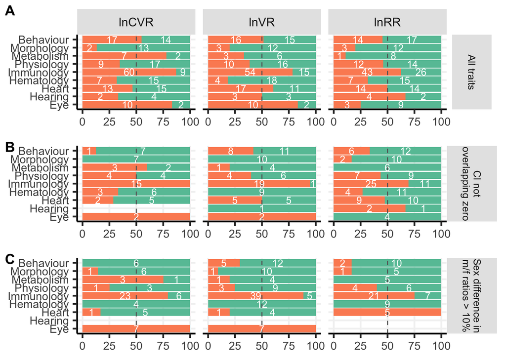

```r
Fig2 <- ggarrange(malebias_Fig2_alltraits, malebias_Fig2_sigtraits,malebias_Fig2_over10, nrow = 3, align = "v", heights = c(1.22,1,1), labels = c("A", "B", "C"))
Fig2
```

```r
ggsave("Fig2.pdf", plot = Fig2, width = 6, height = 5)
```

### Overall results of second order meta anlaysis (Figure 4a)

#### Restructure data for plotting

Data are restructured, and grouping terms are being re-ordered

```r
overall3 <- gather(overall2, parameter, value, c(lnCVR, lnVR, lnRR), factor_key= TRUE)

lnCVR.ci <- overall3 %>% filter(parameter == "lnCVR") %>% mutate(ci.low = lnCVR_lower, ci.high = lnCVR_upper)
lnVR.ci <- overall3 %>% filter(parameter == "lnVR") %>% mutate(ci.low = lnVR_lower, ci.high = lnVR_upper)
lnRR.ci <- overall3 %>% filter(parameter == "lnRR") %>% mutate(ci.low = lnRR_lower, ci.high = lnRR_upper)

overall4 <- bind_rows(lnCVR.ci, lnVR.ci, lnRR.ci) %>% select(GroupingTerm, parameter, value, ci.low, ci.high)

# re-order Grouping Terms

overall4$GroupingTerm <- factor(overall4$GroupingTerm, levels =c("Behaviour","Morphology","Metabolism","Physiology","Immunology","Hematology","Heart","Hearing","Eye", "All") )
overall4$GroupingTerm <- factor(overall4$GroupingTerm, rev(levels(overall4$GroupingTerm)))
overall4$label <- "All traits"

kable(cbind(overall4, overall4)) %>%
  kable_styling() %>%
  scroll_box(width = "100%", height = "200px")
```

| GroupingTerm | parameter | value | ci.low | ci.high | label | GroupingTerm | parameter | value | ci.low | ci.high | label |
| --- | --- | --- | --- | --- | --- | --- | --- | --- | --- | --- | --- |
| Behaviour | lnCVR | -0.0035049 | -0.0240688 | 0.0170591 | All traits | Behaviour | lnCVR | -0.0035049 | -0.0240688 | 0.0170591 | All traits |
| Morphology | lnCVR | 0.0774453 | 0.0414171 | 0.1134734 | All traits | Morphology | lnCVR | 0.0774453 | 0.0414171 | 0.1134734 | All traits |
| Metabolism | lnCVR | -0.0430831 | -0.1125945 | 0.0264283 | All traits | Metabolism | lnCVR | -0.0430831 | -0.1125945 | 0.0264283 | All traits |
| Physiology | lnCVR | 0.0126792 | -0.0140094 | 0.0393678 | All traits | Physiology | lnCVR | 0.0126792 | -0.0140094 | 0.0393678 | All traits |
| Immunology | lnCVR | -0.0681817 | -0.0980135 | -0.0383499 | All traits | Immunology | lnCVR | -0.0681817 | -0.0980135 | -0.0383499 | All traits |
| Hematology | lnCVR | 0.0217865 | -0.0165045 | 0.0600776 | All traits | Hematology | lnCVR | 0.0217865 | -0.0165045 | 0.0600776 | All traits |
| Heart | lnCVR | 0.0183839 | -0.0128375 | 0.0496053 | All traits | Heart | lnCVR | 0.0183839 | -0.0128375 | 0.0496053 | All traits |
| Hearing | lnCVR | 0.0157302 | -0.0111999 | 0.0426603 | All traits | Hearing | lnCVR | 0.0157302 | -0.0111999 | 0.0426603 | All traits |
| Eye | lnCVR | -0.0817932 | -0.1476821 | -0.0159043 | All traits | Eye | lnCVR | -0.0817932 | -0.1476821 | -0.0159043 | All traits |
| All | lnCVR | 0.0046553 | -0.0086242 | 0.0179348 | All traits | All | lnCVR | 0.0046553 | -0.0086242 | 0.0179348 | All traits |
| Behaviour | lnVR | -0.0178345 | -0.0739862 | 0.0383172 | All traits | Behaviour | lnVR | -0.0178345 | -0.0739862 | 0.0383172 | All traits |
| Morphology | lnVR | 0.1514171 | 0.0818826 | 0.2209516 | All traits | Morphology | lnVR | 0.1514171 | 0.0818826 | 0.2209516 | All traits |
| Metabolism | lnVR | 0.0910609 | -0.0337688 | 0.2158905 | All traits | Metabolism | lnVR | 0.0910609 | -0.0337688 | 0.2158905 | All traits |
| Physiology | lnVR | 0.0359821 | -0.0277944 | 0.0997585 | All traits | Physiology | lnVR | 0.0359821 | -0.0277944 | 0.0997585 | All traits |
| Immunology | lnVR | -0.1112382 | -0.1622150 | -0.0602615 | All traits | Immunology | lnVR | -0.1112382 | -0.1622150 | -0.0602615 | All traits |
| Hematology | lnVR | 0.0802111 | 0.0315390 | 0.1288831 | All traits | Hematology | lnVR | 0.0802111 | 0.0315390 | 0.1288831 | All traits |
| Heart | lnVR | -0.0050810 | -0.0357003 | 0.0255383 | All traits | Heart | lnVR | -0.0050810 | -0.0357003 | 0.0255383 | All traits |
| Hearing | lnVR | 0.0106858 | -0.0230440 | 0.0444155 | All traits | Hearing | lnVR | 0.0106858 | -0.0230440 | 0.0444155 | All traits |
| Eye | lnVR | -0.0744497 | -0.1381380 | -0.0107614 | All traits | Eye | lnVR | -0.0744497 | -0.1381380 | -0.0107614 | All traits |
| All | lnVR | 0.0156634 | -0.0077457 | 0.0390726 | All traits | All | lnVR | 0.0156634 | -0.0077457 | 0.0390726 | All traits |
| Behaviour | lnRR | -0.0199206 | -0.0634388 | 0.0235976 | All traits | Behaviour | lnRR | -0.0199206 | -0.0634388 | 0.0235976 | All traits |
| Morphology | lnRR | 0.0678160 | 0.0072225 | 0.1284095 | All traits | Morphology | lnRR | 0.0678160 | 0.0072225 | 0.1284095 | All traits |
| Metabolism | lnRR | 0.1422577 | 0.0364352 | 0.2480801 | All traits | Metabolism | lnRR | 0.1422577 | 0.0364352 | 0.2480801 | All traits |
| Physiology | lnRR | 0.0163695 | -0.0443364 | 0.0770753 | All traits | Physiology | lnRR | 0.0163695 | -0.0443364 | 0.0770753 | All traits |
| Immunology | lnRR | -0.0574840 | -0.1074213 | -0.0075466 | All traits | Immunology | lnRR | -0.0574840 | -0.1074213 | -0.0075466 | All traits |
| Hematology | lnRR | 0.0388537 | -0.0024274 | 0.0801348 | All traits | Hematology | lnRR | 0.0388537 | -0.0024274 | 0.0801348 | All traits |
| Heart | lnRR | -0.0048933 | -0.0324240 | 0.0226374 | All traits | Heart | lnRR | -0.0048933 | -0.0324240 | 0.0226374 | All traits |
| Hearing | lnRR | -0.0132366 | -0.0335982 | 0.0071251 | All traits | Hearing | lnRR | -0.0132366 | -0.0335982 | 0.0071251 | All traits |
| Eye | lnRR | 0.0091186 | 0.0012071 | 0.0170302 | All traits | Eye | lnRR | 0.0091186 | 0.0012071 | 0.0170302 | All traits |
| All | lnRR | 0.0124332 | -0.0061474 | 0.0310138 | All traits | All | lnRR | 0.0124332 | -0.0061474 | 0.0310138 | All traits |

#### Plot FIGURE 4 (Second-order meta analysis results)

Preparation: Sub-Plot for Figure 3: all traits

```r
Metameta_Fig3_alltraits <- overall4 %>%

  ggplot(aes(y= GroupingTerm, x= value)) +
  geom_errorbarh(aes(xmin = ci.low,
                     xmax = ci.high),
               height = 0.1, show.legend = FALSE) +
  geom_point(aes(shape = parameter), fill = 'black',
             color = 'black', size = 2.2,
             show.legend = FALSE) +
  scale_x_continuous(limits=c(-0.24, 0.25),
                     breaks = c(-0.2, -0.1, 0, 0.1, 0.2),
                     name='Effect size') +
  geom_vline(xintercept=0,
             color='black',
             linetype='dashed')+
  facet_grid(cols = vars(parameter), rows = vars(label),
             labeller = label_wrap_gen(width = 23),
             scales= 'free',
             space='free')+
  theme_bw()+
  theme(strip.text.y = element_text(angle = 270, size = 10, margin = margin(t=15, r=15, b=15, l=15)),
      strip.text.x = element_text(size = 12),
        strip.background = element_rect(colour = NULL, linetype = "blank", fill = "gray90"),
        text = element_text(size = 14),
        panel.spacing = unit(0.5, "lines"),
        panel.border= element_blank(),
        axis.line=element_line(),
        panel.grid.major.x = element_line(linetype = "solid", colour = "gray95"),
        panel.grid.major.y = element_line(linetype = "solid", color = "gray95"),
        panel.grid.minor.y = element_blank(),
        panel.grid.minor.x = element_blank(),
        legend.title = element_blank(),
        axis.title.x = element_blank(),
      axis.title.y = element_blank())

#Metameta_Fig3_alltraits
```

#### Figure 4B: Prepare data for traits with CI not overlapping 0

create column with 1= different from zero, 0= zero included in CI Male-biased (significant) traits

```r
meta.male.plot3.sig <- metacombo %>%
        mutate(sigCVR = ifelse(lnCVR_lower > 0, 1, 0),
    sigVR = ifelse(lnVR_lower > 0, 1, 0),
    sigRR = ifelse(lnRR_lower > 0, 1, 0))

#Significant subset for lnCVR
metacombo_male.plot3.CVR <- meta.male.plot3.sig %>%
 filter(sigCVR == 1) %>%
 group_by(GroupingTerm) %>%
 nest()

metacombo_male.plot3.CVR.all <- meta.male.plot3.sig %>%
 filter(sigCVR == 1) %>%
 nest()

#Significant subset for lnVR
metacombo_male.plot3.VR <- meta.male.plot3.sig %>%
 filter(sigVR == 1) %>%
 group_by(GroupingTerm) %>%
 nest()

metacombo_male.plot3.VR.all <- meta.male.plot3.sig %>%
 filter(sigVR == 1) %>%
 nest()

#Significant subset for lnRR
metacombo_male.plot3.RR <- meta.male.plot3.sig %>%
 filter(sigRR == 1) %>%
 group_by(GroupingTerm) %>%
 nest()

metacombo_male.plot3.RR.all <- meta.male.plot3.sig %>%
 filter(sigRR == 1) %>%
 nest()

# **Final fixed effects meta-analyses within grouping terms, with SE of the estimate

plot3.male.meta.CVR <- metacombo_male.plot3.CVR %>%
  mutate(model_lnCVR = map(data, ~ metafor::rma.uni(yi = .x$lnCVR, sei = (.x$lnCVR_upper - .x$lnCVR_lower)/ (2*1.96),
                control=list(optimizer="optim", optmethod="Nelder-Mead", maxit= 1000), verbose=F)) )

plot3.male.meta.VR <- metacombo_male.plot3.VR %>%
  mutate(model_lnVR = map(data, ~ metafor::rma.uni(yi = .x$lnVR, sei = (.x$lnVR_upper - .x$lnVR_lower)/ (2*1.96),
                control=list(optimizer="optim", optmethod="Nelder-Mead", maxit= 1000), verbose=F)) )

plot3.male.meta.RR <- metacombo_male.plot3.RR %>%
  mutate(model_lnRR = map(data, ~ metafor::rma.uni(yi = .x$lnRR, sei = (.x$lnRR_upper - .x$lnRR_lower)/ (2*1.96),
                control=list(optimizer="optim", optmethod="Nelder-Mead", maxit= 1000), verbose=F)) )

# Across all grouping terms #

plot3.male.meta.CVR.all <- metacombo_male.plot3.CVR.all %>%
  mutate(model_lnCVR = map(data, ~ metafor::rma.uni(yi = .x$lnCVR, sei = (.x$lnCVR_upper - .x$lnCVR_lower)/ (2*1.96),
                control=list(optimizer="optim", optmethod="Nelder-Mead", maxit= 1000), verbose=F)) )

plot3.male.meta.CVR.all <- plot3.male.meta.CVR.all %>% mutate(GroupingTerm = "All")

plot3.male.meta.VR.all <- metacombo_male.plot3.VR.all %>%
  mutate(model_lnVR = map(data, ~ metafor::rma.uni(yi = .x$lnVR, sei = (.x$lnVR_upper - .x$lnVR_lower)/ (2*1.96),
                control=list(optimizer="optim", optmethod="Nelder-Mead", maxit= 1000), verbose=F)) )

plot3.male.meta.VR.all <- plot3.male.meta.VR.all %>% mutate(GroupingTerm = "All")

plot3.male.meta.RR.all <- metacombo_male.plot3.RR.all %>%
  mutate(model_lnRR = map(data, ~ metafor::rma.uni(yi = .x$lnRR, sei = (.x$lnRR_upper - .x$lnRR_lower)/ (2*1.96),
                control=list(optimizer="optim", optmethod="Nelder-Mead", maxit= 1000), verbose=F)) )

plot3.male.meta.RR.all <- plot3.male.meta.RR.all %>% mutate(GroupingTerm = "All")

# Combine with separate grouping term results

plot3.male.meta.CVR <- bind_rows(plot3.male.meta.CVR, plot3.male.meta.CVR.all)
plot3.male.meta.VR <- bind_rows(plot3.male.meta.VR, plot3.male.meta.VR.all)
plot3.male.meta.RR <- bind_rows(plot3.male.meta.RR, plot3.male.meta.RR.all)


# **Re-structure data for each grouping term; delete un-used variables

plot3.male.meta.CVR.b <- as.data.frame(plot3.male.meta.CVR %>% group_by(GroupingTerm) %>%
        mutate(lnCVR = map_dbl(model_lnCVR, pluck(2)), lnCVR_lower = map_dbl(model_lnCVR, pluck(6)),
        lnCVR_upper =map_dbl(model_lnCVR, pluck(7)), lnCVR_se =map_dbl(model_lnCVR, pluck(3))) )[, c(1,4:7)]
add.row.hearing <- as.data.frame(t(c("Hearing", NA, NA, NA, NA))) %>% setNames(names(plot3.male.meta.CVR.b))

plot3.male.meta.CVR.b <- bind_rows(plot3.male.meta.CVR.b, add.row.hearing)
plot3.male.meta.CVR.b <- plot3.male.meta.CVR.b[order(plot3.male.meta.CVR.b$GroupingTerm),]

plot3.male.meta.VR.b <- as.data.frame(plot3.male.meta.VR %>% group_by(GroupingTerm) %>%
    mutate(lnVR = map_dbl(model_lnVR, pluck(2)), lnVR_lower = map_dbl(model_lnVR, pluck(6)),
    lnVR_upper =map_dbl(model_lnVR, pluck(7)), lnVR_se =map_dbl(model_lnVR, pluck(3))) )[, c(1,4:7)]
plot3.male.meta.VR.b <- plot3.male.meta.VR.b[order(plot3.male.meta.VR.b$GroupingTerm),]

plot3.male.meta.RR.b <- as.data.frame(plot3.male.meta.RR %>% group_by(GroupingTerm) %>%
    mutate(lnRR = map_dbl(model_lnRR, pluck(2)), lnRR_lower = map_dbl(model_lnRR, pluck(6)),
    lnRR_upper =map_dbl(model_lnRR, pluck(7)), lnRR_se =map_dbl(model_lnRR, pluck(3))) )[, c(1,4:7)]
plot3.male.meta.RR.b <- plot3.male.meta.RR.b[order(plot3.male.meta.RR.b$GroupingTerm),]

overall.male.plot3 <- inner_join(plot3.male.meta.CVR.b, plot3.male.meta.VR.b)
overall.male.plot3 <- inner_join(overall.male.plot3, plot3.male.meta.RR.b)

overall.male.plot3$GroupingTerm <- factor(overall.male.plot3$GroupingTerm, levels =c("Behaviour","Morphology","Metabolism","Physiology","Immunology","Hematology","Heart","Hearing","Eye", "All") )
overall.male.plot3$GroupingTerm <- factor(overall.male.plot3$GroupingTerm, rev(levels(overall.male.plot3$GroupingTerm)))

#add missing GroupingTerms for plot
overall.male.plot3 <- add_row(overall.male.plot3, GroupingTerm = "Behaviour")
overall.male.plot3 <- add_row(overall.male.plot3, GroupingTerm = "Immunology")
overall.male.plot3 <- add_row(overall.male.plot3, GroupingTerm = "Eye")

overall.male.plot3$GroupingTerm <- factor(overall.male.plot3$GroupingTerm, levels =c("Behaviour","Morphology","Metabolism","Physiology","Immunology","Hematology","Heart","Hearing","Eye", "All") )
overall.male.plot3$GroupingTerm <- factor(overall.male.plot3$GroupingTerm, rev(levels(overall.male.plot3$GroupingTerm)))
```

Restructure MALE data for plotting

```r
overall3.male.sig <- gather(overall.male.plot3, parameter, value, c(lnCVR, lnVR, lnRR), factor_key= TRUE)

lnCVR.ci <- overall3.male.sig  %>% filter(parameter == "lnCVR") %>% mutate(ci.low = lnCVR_lower, ci.high = lnCVR_upper)
lnVR.ci <- overall3.male.sig  %>% filter(parameter == "lnVR") %>% mutate(ci.low = lnVR_lower, ci.high = lnVR_upper)
lnRR.ci <- overall3.male.sig  %>% filter(parameter == "lnRR") %>% mutate(ci.low = lnRR_lower, ci.high = lnRR_upper)

overall4.male.sig <- bind_rows(lnCVR.ci, lnVR.ci, lnRR.ci) %>% select(GroupingTerm, parameter, value, ci.low, ci.high)

overall4.male.sig$label <- "CI not overlapping zero"
```

Plot Fig3 all significant results (CI not overlapping zero) for males

```r
######

Metameta_Fig3_male.sig <- overall4.male.sig %>%
  ggplot(aes(y= GroupingTerm, x= value)) +
  geom_errorbarh(aes(xmin = ci.low,
                     xmax = ci.high),
               height = 0.1, show.legend = FALSE) +
  geom_point(aes(shape = parameter),
             fill = 'mediumaquamarine', color = 'mediumaquamarine', size = 2.2,
               show.legend = FALSE) +
  scale_x_continuous(limits=c(0, 0.4),
                     breaks = c(0, 0.3),
                     name='Effect size') +
  geom_vline(xintercept=0,
             color='black',
             linetype='dashed')+
  facet_grid(cols = vars(parameter), rows = vars(label),
             labeller = label_wrap_gen(width = 23),
             scales= 'free',
             space='free')+
  theme_bw()+
  theme(strip.text.y = element_text(angle = 270, size = 10, margin = margin(t=15, r=15, b=15, l=15)),
      strip.text.x = element_text(size = 12),
        strip.background = element_rect(colour = NULL, linetype = "blank", fill = "gray90"),
        text = element_text(size = 14),
        panel.spacing = unit(0.5, "lines"),
        panel.border= element_blank(),
        axis.line=element_line(),
        panel.grid.major.x = element_line(linetype = "solid", colour = "gray95"),
        panel.grid.major.y = element_line(linetype = "solid", color = "gray95"),
        panel.grid.minor.y = element_blank(),
        panel.grid.minor.x = element_blank(),
        legend.title = element_blank(),
        axis.title.x = element_blank(),
      axis.title.y = element_blank())

#Metameta_Fig3_male.sig
```

#### Female Figure, significant traits

Female Fig3 sig

Prepare data for traits with CI not overlapping 0 create column with 1= different from zero, 0= zero included in CI

```r
# female-biased traits

meta.female.plot3.sig <- metacombo %>%
              mutate(sigCVR = ifelse(lnCVR_upper < 0, 1, 0),
              sigVR = ifelse(lnVR_upper < 0, 1, 0),
              sigRR = ifelse(lnRR_upper < 0, 1, 0))

#Significant subset for lnCVR

metacombo_female.plot3.CVR <- meta.female.plot3.sig %>%
filter(sigCVR == 1) %>%
group_by(GroupingTerm) %>%
nest()

metacombo_female.plot3.CVR.all <- meta.female.plot3.sig %>%
 filter(sigCVR == 1) %>%
 nest()

#Significant subset for lnVR

metacombo_female.plot3.VR <- meta.female.plot3.sig %>%
filter(sigVR == 1) %>%
group_by(GroupingTerm) %>%
nest()

metacombo_female.plot3.VR.all <- meta.female.plot3.sig %>%
 filter(sigVR == 1) %>%
 nest()

#Significant subset for lnRR

metacombo_female.plot3.RR <- meta.female.plot3.sig %>%
filter(sigRR == 1) %>%
group_by(GroupingTerm) %>%
nest()

metacombo_female.plot3.RR.all <- meta.female.plot3.sig %>%
 filter(sigRR == 1) %>%
 nest()

# **Final fixed effects meta-analyses within grouping terms, with SE of the estimate

plot3.female.meta.CVR <- metacombo_female.plot3.CVR %>%
  mutate(model_lnCVR = map(data, ~ metafor::rma.uni(yi = .x$lnCVR, sei = (.x$lnCVR_upper - .x$lnCVR_lower)/ (2*1.96),
                                 control=list(optimizer="optim", optmethod="Nelder-Mead", maxit= 1000), verbose=F)) )

plot3.female.meta.VR <- metacombo_female.plot3.VR %>%
  mutate(model_lnVR = map(data, ~ metafor::rma.uni(yi = .x$lnVR, sei = (.x$lnVR_upper - .x$lnVR_lower)/ (2*1.96),
                           control=list(optimizer="optim", optmethod="Nelder-Mead", maxit= 1000), verbose=F)) )

plot3.female.meta.RR <- metacombo_female.plot3.RR %>%
  mutate(model_lnRR = map(data, ~ metafor::rma.uni(yi = .x$lnRR, sei = (.x$lnRR_upper - .x$lnRR_lower)/ (2*1.96),
                                 control=list(optimizer="optim", optmethod="Nelder-Mead", maxit= 1000), verbose=F)) )

# Across all grouping terms #

plot3.female.meta.CVR.all <- metacombo_female.plot3.CVR.all %>%
  mutate(model_lnCVR = map(data, ~ metafor::rma.uni(yi = .x$lnCVR, sei = (.x$lnCVR_upper - .x$lnCVR_lower)/ (2*1.96),
                control=list(optimizer="optim", optmethod="Nelder-Mead", maxit= 1000), verbose=F)) )

plot3.female.meta.CVR.all <- plot3.female.meta.CVR.all %>% mutate(GroupingTerm = "All")

plot3.female.meta.VR.all <- metacombo_female.plot3.VR.all %>%
  mutate(model_lnVR = map(data, ~ metafor::rma.uni(yi = .x$lnVR, sei = (.x$lnVR_upper - .x$lnVR_lower)/ (2*1.96),
                control=list(optimizer="optim", optmethod="Nelder-Mead", maxit= 1000), verbose=F)) )

plot3.female.meta.VR.all <- plot3.female.meta.VR.all %>% mutate(GroupingTerm = "All")

plot3.female.meta.RR.all <- metacombo_female.plot3.RR.all %>%
  mutate(model_lnRR = map(data, ~ metafor::rma.uni(yi = .x$lnRR, sei = (.x$lnRR_upper - .x$lnRR_lower)/ (2*1.96),
                control=list(optimizer="optim", optmethod="Nelder-Mead", maxit= 1000), verbose=F)) )

plot3.female.meta.RR.all <- plot3.female.meta.RR.all %>% mutate(GroupingTerm = "All")

# Combine with separate grouping term results

plot3.female.meta.CVR <- bind_rows(plot3.female.meta.CVR, plot3.female.meta.CVR.all)
plot3.female.meta.VR <- bind_rows(plot3.female.meta.VR, plot3.female.meta.VR.all)
plot3.female.meta.RR <- bind_rows(plot3.female.meta.RR, plot3.female.meta.RR.all)


# **Re-structure data for each grouping term; delete un-used variables

plot3.female.meta.CVR.b <- as.data.frame(plot3.female.meta.CVR %>% group_by(GroupingTerm) %>%
                             mutate(lnCVR = map_dbl(model_lnCVR, pluck(2)), lnCVR_lower = map_dbl(model_lnCVR, pluck(6)),
                             lnCVR_upper =map_dbl(model_lnCVR, pluck(7)), lnCVR_se =map_dbl(model_lnCVR, pluck(3))) )[, c(1,4:7)]

add.row.hearing <- as.data.frame(t(c("Hearing", NA, NA, NA, NA))) %>% setNames(names(plot3.female.meta.CVR.b))

plot3.female.meta.CVR.b <- bind_rows(plot3.female.meta.CVR.b, add.row.hearing)
plot3.female.meta.CVR.b <- plot3.female.meta.CVR.b[order(plot3.female.meta.CVR.b$GroupingTerm),]

plot3.female.meta.VR.b <- as.data.frame(plot3.female.meta.VR %>% group_by(GroupingTerm) %>%
              mutate(lnVR = map_dbl(model_lnVR, pluck(2)), lnVR_lower = map_dbl(model_lnVR, pluck(6)),
              lnVR_upper =map_dbl(model_lnVR, pluck(7)), lnVR_se =map_dbl(model_lnVR, pluck(3))) )[, c(1,4:7)]

plot3.female.meta.VR.b <- plot3.female.meta.VR.b[order(plot3.female.meta.VR.b$GroupingTerm),]

plot3.female.meta.RR.b <- as.data.frame(plot3.female.meta.RR %>% group_by(GroupingTerm) %>%
              mutate(lnRR = map_dbl(model_lnRR, pluck(2)), lnRR_lower = map_dbl(model_lnRR, pluck(6)),
              lnRR_upper =map_dbl(model_lnRR, pluck(7)), lnRR_se =map_dbl(model_lnRR, pluck(3))) )[, c(1,4:7)]

plot3.female.meta.RR.b <- plot3.female.meta.RR.b[order(plot3.female.meta.RR.b$GroupingTerm),]

overall.female.plot3 <- full_join(plot3.female.meta.CVR.b, plot3.female.meta.VR.b)
overall.female.plot3 <- full_join(overall.female.plot3, plot3.female.meta.RR.b)

overall.female.plot3$GroupingTerm <- factor(overall.female.plot3$GroupingTerm, levels =c("Behaviour","Morphology","Metabolism","Physiology","Immunology","Hematology","Heart","Hearing","Eye", "All") )
overall.female.plot3$GroupingTerm <- factor(overall.female.plot3$GroupingTerm, rev(levels(overall.female.plot3$GroupingTerm)))

#add missing GroupingTerms for plot POTENTIALLY DELETE
#overall.female.plot3 <- add_row(overall.female.plot3, GroupingTerm = "Morphology")
#overall.female.plot3 <- add_row(overall.female.plot3, GroupingTerm = "Metabolism")
#overall.female.plot3 <- add_row(overall.female.plot3, GroupingTerm = "Hematology")
#overall.female.plot3 <- add_row(overall.female.plot3, GroupingTerm = "Hearing")
#overall.female.plot3 <- add_row(overall.female.plot3, GroupingTerm = "Eye")

#overall.female.plot3$GroupingTerm <- factor(overall.female.plot3$GroupingTerm, levels =c("Behaviour","Morphology","Metabolism","Physiology","Immunology","Hematology","Heart","Hearing","Eye", "All") )
#overall.female.plot3$GroupingTerm <- factor(overall.female.plot3$GroupingTerm, rev(levels(overall.female.plot3$GroupingTerm)))
```

Restructure data for plotting

```r
overall3.female.sig <- gather(overall.female.plot3, parameter, value, c(lnCVR, lnVR, lnRR), factor_key= TRUE)

lnCVR.ci <- overall3.female.sig  %>% filter(parameter == "lnCVR") %>% mutate(ci.low = lnCVR_lower, ci.high = lnCVR_upper)
lnVR.ci <- overall3.female.sig  %>% filter(parameter == "lnVR") %>% mutate(ci.low = lnVR_lower, ci.high = lnVR_upper)
lnRR.ci <- overall3.female.sig  %>% filter(parameter == "lnRR") %>% mutate(ci.low = lnRR_lower, ci.high = lnRR_upper)

overall4.female.sig <- bind_rows(lnCVR.ci, lnVR.ci, lnRR.ci) %>% select(GroupingTerm, parameter, value, ci.low, ci.high)

overall4.female.sig$label <- "CI not overlapping zero"
```

Plot Fig3 all significant results (CI not overlapping zero, female )

```r
Metameta_Fig3_female.sig <- overall4.female.sig %>%
  ggplot(aes(y= GroupingTerm, x= value)) +
  geom_errorbarh(aes(xmin = ci.low,
                     xmax = ci.high),
                     height = 0.1, show.legend = FALSE) +
  geom_point(aes(shape = parameter),
             fill = 'salmon1', color = 'salmon1', size = 2.2,
             show.legend = FALSE) +
  scale_x_continuous(limits=c(-0.4, 0),
                     breaks = c(-0.3 ,0),
                     name='Effect size') +
  geom_vline(xintercept=0,
             color='black',
             linetype='dashed')+
  facet_grid(cols = vars(parameter), #rows = vars(label),
             #labeller = label_wrap_gen(width = 23),
             scales= 'free',
             space='free')+
  theme_bw()+
  theme(strip.text.y = element_text(angle = 270, size = 10, margin = margin(t=15, r=15, b=15, l=15)),
                strip.text.x = element_text(size = 12),
        strip.background = element_rect(colour = NULL, linetype = "blank", fill = "gray90"),
        text = element_text(size = 14),
        panel.spacing = unit(0.5, "lines"),
        panel.border= element_blank(),
        axis.line=element_line(),
        panel.grid.major.x = element_line(linetype = "solid", colour = "gray95"),
        panel.grid.major.y = element_line(linetype = "solid", color = "gray95"),
        panel.grid.minor.y = element_blank(),
        panel.grid.minor.x = element_blank(),
        legend.title = element_blank(),
        axis.title.x = element_blank(),
                axis.title.y = element_blank())

#Metameta_Fig3_female.sig
```

#### Fig4 C >10%

Prepare data for traits with m/f difference > 10%

create column with 1= larger, 0= diff not larger than 10%

#### Male Fig 3 > 10% (male biased traits)

```r
meta.male.plot3.perc <- metacombo %>%
        mutate(percCVR = ifelse(lnCVR > log (11/10), 1, 0),
    percVR = ifelse(lnVR > log (11/10), 1, 0),
    percRR = ifelse(lnRR > log (11/10), 1, 0))

#Significant subset for lnCVR
metacombo_male.plot3.CVR.perc <- meta.male.plot3.perc %>%
 filter(percCVR == 1) %>%
 group_by(GroupingTerm) %>%
 nest()

metacombo_male.plot3.CVR.perc.all <- meta.male.plot3.perc %>%
 filter(percCVR == 1) %>%
 nest()

#Significant subset for lnVR
metacombo_male.plot3.VR.perc <- meta.male.plot3.perc %>%
 filter(percVR == 1) %>%
 group_by(GroupingTerm) %>%
 nest()

metacombo_male.plot3.VR.perc.all <- meta.male.plot3.perc %>%
 filter(percVR == 1) %>%
 nest()

#Significant subset for lnRR
metacombo_male.plot3.RR.perc <- meta.male.plot3.perc %>%
 filter(percRR == 1) %>%
 group_by(GroupingTerm) %>%
 nest()

metacombo_male.plot3.RR.perc.all <- meta.male.plot3.perc %>%
 filter(percRR == 1) %>%
 nest()


# **Final fixed effects meta-analyses within grouping terms and across grouping terms, with SE of the estimate

plot3.male.meta.CVR.perc <- metacombo_male.plot3.CVR.perc %>%
  mutate(model_lnCVR = map(data, ~ metafor::rma.uni(yi = .x$lnCVR, sei = (.x$lnCVR_upper - .x$lnCVR_lower)/ (2*1.96),
                control=list(optimizer="optim", optmethod="Nelder-Mead", maxit= 1000), verbose=F)) )

plot3.male.meta.VR.perc <- metacombo_male.plot3.VR.perc %>%
  mutate(model_lnVR = map(data, ~ metafor::rma.uni(yi = .x$lnVR, sei = (.x$lnVR_upper - .x$lnVR_lower)/ (2*1.96),
                control=list(optimizer="optim", optmethod="Nelder-Mead", maxit= 1000), verbose=F)) )

plot3.male.meta.RR.perc <- metacombo_male.plot3.RR.perc %>%
  mutate(model_lnRR = map(data, ~ metafor::rma.uni(yi = .x$lnRR, sei = (.x$lnRR_upper - .x$lnRR_lower)/ (2*1.96),
                control=list(optimizer="optim", optmethod="Nelder-Mead", maxit= 1000), verbose=F)) )

# Across all grouping terms #

plot3.male.meta.CVR.perc.all <- metacombo_male.plot3.CVR.perc.all %>%
  mutate(model_lnCVR = map(data, ~ metafor::rma.uni(yi = .x$lnCVR, sei = (.x$lnCVR_upper - .x$lnCVR_lower)/ (2*1.96),
                control=list(optimizer="optim", optmethod="Nelder-Mead", maxit= 1000), verbose=F)) )

plot3.male.meta.CVR.perc.all <- plot3.male.meta.CVR.perc.all %>% mutate(GroupingTerm = "All")

plot3.male.meta.VR.perc.all <- metacombo_male.plot3.VR.perc.all %>%
  mutate(model_lnVR = map(data, ~ metafor::rma.uni(yi = .x$lnVR, sei = (.x$lnVR_upper - .x$lnVR_lower)/ (2*1.96),
                control=list(optimizer="optim", optmethod="Nelder-Mead", maxit= 1000), verbose=F)) )

plot3.male.meta.VR.perc.all <- plot3.male.meta.VR.perc.all %>% mutate(GroupingTerm = "All")

plot3.male.meta.RR.perc.all <- metacombo_male.plot3.RR.perc.all %>%
  mutate(model_lnRR = map(data, ~ metafor::rma.uni(yi = .x$lnRR, sei = (.x$lnRR_upper - .x$lnRR_lower)/ (2*1.96),
                control=list(optimizer="optim", optmethod="Nelder-Mead", maxit= 1000), verbose=F)) )

plot3.male.meta.RR.perc.all <- plot3.male.meta.RR.perc.all %>% mutate(GroupingTerm = "All")

# Combine with separate grouping term results

plot3.male.meta.CVR.perc <- bind_rows(plot3.male.meta.CVR.perc, plot3.male.meta.CVR.perc.all)
plot3.male.meta.VR.perc <- bind_rows(plot3.male.meta.VR.perc, plot3.male.meta.VR.perc.all)
plot3.male.meta.RR.perc <- bind_rows(plot3.male.meta.RR.perc, plot3.male.meta.RR.perc.all)


# **Re-structure data for each grouping term; delete un-used variables: "Hearing missing for all 3 parameters"

plot3.male.meta.CVR.perc.b <- as.data.frame(plot3.male.meta.CVR.perc %>% group_by(GroupingTerm) %>%
        mutate(lnCVR = map_dbl(model_lnCVR, pluck(2)), lnCVR_lower = map_dbl(model_lnCVR, pluck(6)),
        lnCVR_upper =map_dbl(model_lnCVR, pluck(7)), lnCVR_se =map_dbl(model_lnCVR, pluck(3))) )[, c(1,4:7)]
add.row.hearing <- as.data.frame(t(c("Hearing", NA, NA, NA, NA))) %>% setNames(names(plot3.male.meta.CVR.perc.b))
plot3.male.meta.CVR.perc.b <- rbind(plot3.male.meta.CVR.perc.b, add.row.hearing)
plot3.male.meta.CVR.perc.b <- plot3.male.meta.CVR.perc.b[order(plot3.male.meta.CVR.perc.b$GroupingTerm),]

plot3.male.meta.VR.perc.b <- as.data.frame(plot3.male.meta.VR.perc %>% group_by(GroupingTerm) %>%
    mutate(lnVR = map_dbl(model_lnVR, pluck(2)), lnVR_lower = map_dbl(model_lnVR, pluck(6)),
    lnVR_upper =map_dbl(model_lnVR, pluck(7)), lnVR_se =map_dbl(model_lnVR, pluck(3))) )[, c(1,4:7)]
add.row.hearing <- as.data.frame(t(c("Hearing", NA, NA, NA, NA))) %>% setNames(names(plot3.male.meta.VR.perc.b))
plot3.male.meta.VR.perc.b <- rbind(plot3.male.meta.VR.perc.b, add.row.hearing)
plot3.male.meta.VR.perc.b <- plot3.male.meta.VR.perc.b[order(plot3.male.meta.VR.perc.b$GroupingTerm),]

plot3.male.meta.RR.perc.b <- as.data.frame(plot3.male.meta.RR.perc %>% group_by(GroupingTerm) %>%
    mutate(lnRR = map_dbl(model_lnRR, pluck(2)), lnRR_lower = map_dbl(model_lnRR, pluck(6)),
    lnRR_upper =map_dbl(model_lnRR, pluck(7)), lnRR_se =map_dbl(model_lnRR, pluck(3))) )[, c(1,4:7)]
add.row.hearing <- as.data.frame(t(c("Hearing", NA, NA, NA, NA))) %>%
  setNames(names(plot3.male.meta.RR.perc.b))
plot3.male.meta.RR.perc.b <- rbind(plot3.male.meta.RR.perc.b, add.row.hearing)

add.row.eye <- as.data.frame(t(c("Eye", NA, NA, NA, NA))) %>%
  setNames(names(plot3.male.meta.RR.perc.b))
plot3.male.meta.RR.perc.b <- rbind(plot3.male.meta.RR.perc.b, add.row.eye)

plot3.male.meta.RR.perc.b <- plot3.male.meta.RR.perc.b[order(plot3.male.meta.RR.perc.b$GroupingTerm),]

overall.male.plot3.perc <- full_join(plot3.male.meta.CVR.perc.b, plot3.male.meta.VR.perc.b)
overall.male.plot3.perc <- full_join(overall.male.plot3.perc, plot3.male.meta.RR.perc.b)


overall.male.plot3.perc$GroupingTerm <- factor(overall.male.plot3.perc$GroupingTerm, levels =c("Behaviour","Morphology","Metabolism","Physiology","Immunology","Hematology","Heart","Hearing","Eye", "All") )
overall.male.plot3.perc$GroupingTerm <- factor(overall.male.plot3.perc$GroupingTerm, rev(levels(overall.male.plot3.perc$GroupingTerm)))
```

Restructure data for plotting : Male biased, 10% difference

```r
overall3.perc <- gather(overall.male.plot3.perc, parameter, value, c(lnCVR, lnVR, lnRR), factor_key= TRUE)

lnCVR.ci <- overall3.perc %>% filter(parameter == "lnCVR") %>% mutate(ci.low = lnCVR_lower, ci.high = lnCVR_upper)
lnVR.ci <- overall3.perc  %>% filter(parameter == "lnVR") %>% mutate(ci.low = lnVR_lower, ci.high = lnVR_upper)
lnRR.ci <- overall3.perc  %>% filter(parameter == "lnRR") %>% mutate(ci.low = lnRR_lower, ci.high = lnRR_upper)

overall4.male.perc <- bind_rows(lnCVR.ci, lnVR.ci, lnRR.ci) %>% select(GroupingTerm, parameter, value, ci.low, ci.high)

overall4.male.perc$label <- "Sex difference in m/f ratios > 10%"

overall4.male.perc$value <- as.numeric(overall4.male.perc$value)
overall4.male.perc$ci.low  <- as.numeric(overall4.male.perc$ci.low)
overall4.male.perc$ci.high <- as.numeric(overall4.male.perc$ci.high)
```

Plot Fig3 all >10% difference (male bias)

```r
Metameta_Fig3_male.perc <- overall4.male.perc %>% #filter(., GroupingTerm != "Hearing") %>%
  ggplot(aes(y= GroupingTerm, x= value)) +
  geom_errorbarh(aes(xmin = ci.low,
                     xmax = ci.high),
               height = 0.1, show.legend = FALSE) +
  geom_point(aes(shape = parameter,
             fill = parameter), color = 'mediumaquamarine', size = 2.2,
             show.legend = FALSE) +
  scale_x_continuous(limits=c(-0.2, 0.62),
                     breaks = c(0, 0.3),
                     name='Effect size') +
  geom_vline(xintercept=0,
             color='black',
             linetype='dashed')+
  facet_grid(cols = vars(parameter), rows = vars(label),
             labeller = label_wrap_gen(width = 23),
             scales= 'free',
             space='free')+
  theme_bw()+
  theme(strip.text.y = element_text(angle = 270, size = 10, margin = margin(t=15, r=15, b=15, l=15)),
      strip.text.x = element_blank(),
        strip.background = element_rect(colour = NULL, linetype = "blank", fill = "gray90"),
        text = element_text(size = 14),
        panel.spacing = unit(0.5, "lines"),
        panel.border= element_blank(),
        axis.line=element_line(),
        panel.grid.major.x = element_line(linetype = "solid", colour = "gray95"),
        panel.grid.major.y = element_line(linetype = "solid", color = "gray95"),
        panel.grid.minor.y = element_blank(),
        panel.grid.minor.x = element_blank(),
        legend.title = element_blank(),
        axis.title.x = element_text(hjust = 0.5, size = 14),
      axis.title.y = element_blank())

# Metameta_Fig3_male.perc
```

Female Fig 3 >10%

```r
meta.plot3.perc <- metacombo %>%
        mutate(percCVR = ifelse(lnCVR < log (9/10), 1, 0),
    percVR = ifelse(lnVR < log (9/10), 1, 0),
    percRR = ifelse(lnRR < log (9/10), 1, 0))

#Significant subset for lnCVR
metacombo_plot3.CVR.perc <- meta.plot3.perc %>%
 filter(percCVR == 1) %>%
 group_by(GroupingTerm) %>%
 nest()

metacombo_plot3.CVR.perc.all <- meta.plot3.perc %>%
 filter(percCVR == 1) %>%
 nest()

#Significant subset for lnVR
metacombo_plot3.VR.perc <- meta.plot3.perc %>%
 filter(percVR == 1) %>%
 group_by(GroupingTerm) %>%
 nest()

metacombo_plot3.VR.perc.all <- meta.plot3.perc %>%
 filter(percVR == 1) %>%
 nest()

#Significant subset for lnRR
metacombo_plot3.RR.perc <- meta.plot3.perc %>%
 filter(percRR == 1) %>%
 group_by(GroupingTerm) %>%
 nest()

metacombo_plot3.RR.perc.all <- meta.plot3.perc %>%
 filter(percRR == 1) %>%
 nest()


# **Final fixed effects meta-analyses within grouping terms, with SE of the estimate

plot3.meta.CVR.perc <- metacombo_plot3.CVR.perc %>%
  mutate(model_lnCVR = map(data, ~ metafor::rma.uni(yi = .x$lnCVR, sei = (.x$lnCVR_upper - .x$lnCVR_lower)/ (2*1.96),
                control=list(optimizer="optim", optmethod="Nelder-Mead", maxit= 1000), verbose=F)) )

plot3.meta.VR.perc <- metacombo_plot3.VR.perc %>%
  mutate(model_lnVR = map(data, ~ metafor::rma.uni(yi = .x$lnVR, sei = (.x$lnVR_upper - .x$lnVR_lower)/ (2*1.96),
                control=list(optimizer="optim", optmethod="Nelder-Mead", maxit= 1000), verbose=F)) )

plot3.meta.RR.perc <- metacombo_plot3.RR.perc %>%
  mutate(model_lnRR = map(data, ~ metafor::rma.uni(yi = .x$lnRR, sei = (.x$lnRR_upper - .x$lnRR_lower)/ (2*1.96),
                control=list(optimizer="optim", optmethod="Nelder-Mead", maxit= 1000), verbose=F)) )

# Across all grouping terms #

plot3.meta.CVR.perc.all <- metacombo_plot3.CVR.perc.all %>%
  mutate(model_lnCVR = map(data, ~ metafor::rma.uni(yi = .x$lnCVR, sei = (.x$lnCVR_upper - .x$lnCVR_lower)/ (2*1.96),
                control=list(optimizer="optim", optmethod="Nelder-Mead", maxit= 1000), verbose=F)) )

plot3.meta.CVR.perc.all <- plot3.meta.CVR.perc.all %>% mutate(GroupingTerm = "All")

plot3.meta.VR.perc.all <- metacombo_plot3.VR.perc.all %>%
  mutate(model_lnVR = map(data, ~ metafor::rma.uni(yi = .x$lnVR, sei = (.x$lnVR_upper - .x$lnVR_lower)/ (2*1.96),
                control=list(optimizer="optim", optmethod="Nelder-Mead", maxit= 1000), verbose=F)) )

plot3.meta.VR.perc.all <- plot3.meta.VR.perc.all %>% mutate(GroupingTerm = "All")

plot3.meta.RR.perc.all <- metacombo_plot3.RR.perc.all %>%
  mutate(model_lnRR = map(data, ~ metafor::rma.uni(yi = .x$lnRR, sei = (.x$lnRR_upper - .x$lnRR_lower)/ (2*1.96),
                control=list(optimizer="optim", optmethod="Nelder-Mead", maxit= 1000), verbose=F)) )

plot3.meta.RR.perc.all <- plot3.meta.RR.perc.all %>% mutate(GroupingTerm = "All")

# Combine with separate grouping term results

plot3.meta.CVR.perc <- bind_rows(plot3.meta.CVR.perc, plot3.meta.CVR.perc.all)
plot3.meta.VR.perc <- bind_rows(plot3.meta.VR.perc, plot3.meta.VR.perc.all)
plot3.meta.RR.perc <- bind_rows(plot3.meta.RR.perc, plot3.meta.RR.perc.all)


# **Re-structure data for each grouping term; delete un-used variables: "Hearing missing for all 3 parameters"

plot3.meta.CVR.perc.b <- as.data.frame(plot3.meta.CVR.perc %>% group_by(GroupingTerm) %>%
        mutate(lnCVR = map_dbl(model_lnCVR, pluck(2)), lnCVR_lower = map_dbl(model_lnCVR, pluck(6)),
        lnCVR_upper =map_dbl(model_lnCVR, pluck(7)), lnCVR_se =map_dbl(model_lnCVR, pluck(3))) )[, c(1,4:7)]
add.row.hearing <- as.data.frame(t(c("Hearing", NA, NA, NA, NA))) %>% setNames(names(plot3.meta.CVR.perc.b))
plot3.meta.CVR.perc.b <- rbind(plot3.meta.CVR.perc.b, add.row.hearing)
plot3.meta.CVR.perc.b <- plot3.meta.CVR.perc.b[order(plot3.meta.CVR.perc.b$GroupingTerm),]

plot3.meta.VR.perc.b <- as.data.frame(plot3.meta.VR.perc %>% group_by(GroupingTerm) %>%
    mutate(lnVR = map_dbl(model_lnVR, pluck(2)), lnVR_lower = map_dbl(model_lnVR, pluck(6)),
    lnVR_upper =map_dbl(model_lnVR, pluck(7)), lnVR_se =map_dbl(model_lnVR, pluck(3))) )[, c(1,4:7)]
add.row.hearing <- as.data.frame(t(c("Hearing", NA, NA, NA, NA))) %>% setNames(names(plot3.meta.VR.perc.b))
plot3.meta.VR.perc.b <- rbind(plot3.meta.VR.perc.b, add.row.hearing)
plot3.meta.VR.perc.b <- plot3.meta.VR.perc.b[order(plot3.meta.VR.perc.b$GroupingTerm),]

plot3.meta.RR.perc.b <- as.data.frame(plot3.meta.RR.perc %>% group_by(GroupingTerm) %>%
    mutate(lnRR = map_dbl(model_lnRR, pluck(2)), lnRR_lower = map_dbl(model_lnRR, pluck(6)),
    lnRR_upper =map_dbl(model_lnRR, pluck(7)), lnRR_se =map_dbl(model_lnRR, pluck(3))) )[, c(1,4:7)]
add.row.hearing <- as.data.frame(t(c("Hearing", NA, NA, NA, NA))) %>% setNames(names(plot3.meta.RR.perc.b))
plot3.meta.RR.perc.b <- rbind(plot3.meta.RR.perc.b, add.row.hearing)
add.row.hematology <- as.data.frame(t(c("Hematology", NA, NA, NA, NA))) %>%
  setNames(names(plot3.meta.RR.perc.b))
plot3.meta.RR.perc.b <- rbind(plot3.meta.RR.perc.b, add.row.hematology)


plot3.meta.RR.perc.b <- plot3.meta.RR.perc.b[order(plot3.meta.RR.perc.b$GroupingTerm),]

overall.plot3.perc <- full_join(plot3.meta.CVR.perc.b, plot3.meta.VR.perc.b)
overall.plot3.perc <- full_join(overall.plot3.perc, plot3.meta.RR.perc.b)


overall.plot3.perc$GroupingTerm <- factor(overall.plot3.perc$GroupingTerm, levels =c("Behaviour","Morphology","Metabolism","Physiology","Immunology","Hematology","Heart","Hearing","Eye", "All") )
overall.plot3.perc$GroupingTerm <- factor(overall.plot3.perc$GroupingTerm, rev(levels(overall.plot3.perc$GroupingTerm)))
```

#### Restructure data for plotting

Female bias, 10 percent difference

```r
overall3.perc <- gather(overall.plot3.perc, parameter, value, c(lnCVR, lnVR, lnRR), factor_key= TRUE)

lnCVR.ci <- overall3.perc %>% filter(parameter == "lnCVR") %>% mutate(ci.low = lnCVR_lower, ci.high = lnCVR_upper)
lnVR.ci <- overall3.perc  %>% filter(parameter == "lnVR") %>% mutate(ci.low = lnVR_lower, ci.high = lnVR_upper)
lnRR.ci <- overall3.perc  %>% filter(parameter == "lnRR") %>% mutate(ci.low = lnRR_lower, ci.high = lnRR_upper)

overall4.perc <- bind_rows(lnCVR.ci, lnVR.ci, lnRR.ci) %>% select(GroupingTerm, parameter, value, ci.low, ci.high)

overall4.perc$label <- "Sex difference in m/f ratios > 10%"

overall4.perc$value <- as.numeric(overall4.perc$value)
overall4.perc$ci.low  <- as.numeric(overall4.perc$ci.low)
overall4.perc$ci.high <- as.numeric(overall4.perc$ci.high)
```

Plot Fig3 all >10% difference (female)

```r
Metameta_Fig3_female.perc <- overall4.perc %>%
  ggplot(aes(y= GroupingTerm, x= value)) +
  geom_errorbarh(aes(xmin = ci.low,
                     xmax = ci.high),
               height = 0.1, show.legend = FALSE) +
  geom_point(aes(shape = parameter),
             fill = 'salmon1', color = 'salmon1', size = 2.2,
             show.legend = FALSE) +

#scale_shape_manual(values =

  scale_x_continuous(limits=c(-0.53, 0.2),
                     breaks = c(-0.3, 0),
                     name='Effect size') +
  geom_vline(xintercept=0,
             color='black',
             linetype='dashed')+
  facet_grid(cols = vars(parameter), #rows = vars(label),
             #labeller = label_wrap_gen(width = 23),
             scales= 'free',
             space='free')+
  theme_bw()+
  theme(strip.text.y = element_text(angle = 270, size = 10, margin = margin(t=15, r=15, b=15, l=15)),
      strip.text.x = element_blank(),
        strip.background = element_rect(colour = NULL, linetype = "blank", fill = "gray90"),
        text = element_text(size = 14),
        panel.spacing = unit(0.5, "lines"),
        panel.border= element_blank(),
        axis.line=element_line(),
        panel.grid.major.x = element_line(linetype = "solid", colour = "gray95"),
        panel.grid.major.y = element_line(linetype = "solid", color = "gray95"),
        panel.grid.minor.y = element_blank(),
        panel.grid.minor.x = element_blank(),
        legend.title = element_blank(),
        axis.title.x = element_text(hjust = 0.5, size = 14),
      axis.title.y = element_blank())


#Metameta_Fig3_female.perc
```

#### Plot Fig3 all plots combined

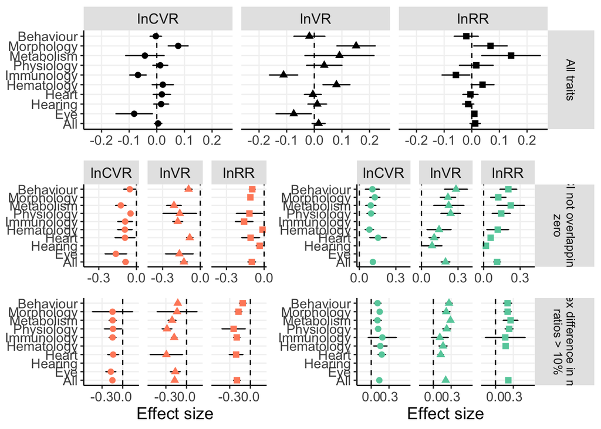

```r
library(ggpubr)
Fig3.bottom <- ggarrange(Metameta_Fig3_female.sig, Metameta_Fig3_male.sig, Metameta_Fig3_female.perc, Metameta_Fig3_male.perc,
           ncol = 2, nrow = 2, widths = c(1, 1.20), heights = c(1, 1))

Fig3 <- ggarrange(Metameta_Fig3_alltraits, Fig3.bottom, ncol = 1, nrow = 2, heights = c(1.4, 2.5))
Fig3
```

```r
#ggsave("Fig3.pdf", plot = Fig3, width = 9, height = 6)
```

### Heterogeneity

#### FIGURE 4 (Second-order meta analysis on heterogeneity)

#### Create matrix to store results for all traits

```r
results.allhetero.grouping <- as.data.frame(cbind(c(1:n), matrix(rep(0, n*30), ncol = 30)))
names(results.allhetero.grouping) <- c("id", "sigma2_strain.CVR", "sigma2_center.CVR", "sigma2_error.CVR", "s.nlevels.strain.CVR",
    "s.nlevels.center.CVR", "s.nlevels.error.CVR", "sigma2_strain.VR", "sigma2_center.VR", "sigma2_error.VR", "s.nlevels.strain.VR",
    "s.nlevels.center.VR", "s.nlevels.error.VR", "sigma2_strain.RR", "sigma2_center.RR", "sigma2_error.RR", "s.nlevels.strain.RR",
    "s.nlevels.center.RR", "s.nlevels.error.RR", "lnCVR", "lnCVR_lower", "lnCVR_upper", "lnCVR_se", "lnVR", "lnVR_lower", "lnVR_upper",
    "lnVR_se", "lnRR", "lnRR_lower", "lnRR_upper" ,"lnRR_se")
```

#### LOOP

Parameters to extract from metafor (sigma2’s, s.nlevels)

```r
for(t in 1:n) {
  tryCatch({

    data_par_age <- data_subset_parameterid_individual_by_age(data, t, age_min = 0, age_center = 100)

    population_stats <- calculate_population_stats(data_par_age)

    results <- create_meta_analysis_effect_sizes(population_stats)

    # lnCVR, logaritm of the ratio of male and female coefficients of variance

    cvr. <- metafor::rma.mv(yi = effect_size_CVR, V = sample_variance_CVR, random = list(~1| strain_name, ~1|production_center,
                                ~1|err), control=list(optimizer="optim", optmethod="Nelder-Mead", maxit= 1000), data = results)
    results.allhetero.grouping[t, 2] <- cvr.$sigma2[1]
    results.allhetero.grouping[t, 3] <- cvr.$sigma2[2]
    results.allhetero.grouping[t, 4] <- cvr.$sigma2[3]
    results.allhetero.grouping[t, 5] <- cvr.$s.nlevels[1]
    results.allhetero.grouping[t, 6] <- cvr.$s.nlevels[2]
    results.allhetero.grouping[t, 7] <- cvr.$s.nlevels[3]
     results.allhetero.grouping[t, 20] <- cvr.$b
     results.allhetero.grouping[t, 21] <- cvr.$ci.lb
     results.allhetero.grouping[t, 22] <- cvr.$ci.ub
     results.allhetero.grouping[t, 23] <- cvr.$se

    # lnVR, male to female variability ratio (logarithm of male and female standard deviations)

    vr. <- metafor::rma.mv(yi = effect_size_VR, V = sample_variance_VR, random = list(~1| strain_name, ~1|production_center,
                                ~1|err), control=list(optimizer="optim", optmethod="Nelder-Mead", maxit= 1000), data = results)
    results.allhetero.grouping[t, 8] <- vr.$sigma2[1]
    results.allhetero.grouping[t, 9] <- vr.$sigma2[2]
    results.allhetero.grouping[t, 10] <- vr.$sigma2[3]
    results.allhetero.grouping[t, 11] <- vr.$s.nlevels[1]
    results.allhetero.grouping[t, 12] <- vr.$s.nlevels[2]
    results.allhetero.grouping[t, 13] <- vr.$s.nlevels[3]
     results.allhetero.grouping[t, 24] <- vr.$b
     results.allhetero.grouping[t, 25] <- vr.$ci.lb
     results.allhetero.grouping[t, 26] <- vr.$ci.ub
     results.allhetero.grouping[t, 27] <- vr.$se

    # lnRR, response ratio (logarithm of male and female means)

    rr. <- metafor::rma.mv(yi = effect_size_RR, V = sample_variance_RR, random = list(~1| strain_name, ~1|production_center,
                                ~1|err), control=list(optimizer="optim", optmethod="Nelder-Mead", maxit= 1000), data = results)
    results.allhetero.grouping[t, 14] <- rr.$sigma2[1]
    results.allhetero.grouping[t, 15] <- rr.$sigma2[2]
    results.allhetero.grouping[t, 16] <- rr.$sigma2[3]
    results.allhetero.grouping[t, 17] <- rr.$s.nlevels[1]
    results.allhetero.grouping[t, 18] <- rr.$s.nlevels[2]
    results.allhetero.grouping[t, 19] <- rr.$s.nlevels[3]
     results.allhetero.grouping[t, 28] <- rr.$b
     results.allhetero.grouping[t, 29] <- rr.$ci.lb
     results.allhetero.grouping[t, 30] <- rr.$ci.ub
     results.allhetero.grouping[t, 31] <- rr.$se

  }, error=function(e){cat("ERROR :",conditionMessage(e), "\n")})
}
```

```
## ERROR : Optimizer (optim) did not achieve convergence (convergence = 10).
## ERROR : Optimizer (optim) did not achieve convergence (convergence = 10).
## ERROR : NA/NaN/Inf in 'y'
## ERROR : NA/NaN/Inf in 'y'
## ERROR : NA/NaN/Inf in 'y'
## ERROR : NA/NaN/Inf in 'y'
## ERROR : NA/NaN/Inf in 'y'
## ERROR : NA/NaN/Inf in 'y'
## ERROR : NA/NaN/Inf in 'y'
## ERROR : NA/NaN/Inf in 'y'
```

#### Exclude traits

```r
results.allhetero.grouping2 <- results.allhetero.grouping[results.allhetero.grouping$s.nlevels.strain.VR != 0, ]
nrow(results.allhetero.grouping2) #218
```

```
## [1] 223
```

Merge data sets containing metafor results with procedure etc. names

```r
#procedures <- read.csv("../procedures.csv")

results.allhetero.grouping2$parameter_group <- data$parameter_group[match(results.allhetero.grouping2$id, data$id)]
results.allhetero.grouping2$procedure <- data$procedure_name[match(results.allhetero.grouping2$id, data$id)]

results.allhetero.grouping2$GroupingTerm <-  procedures$GroupingTerm[match(results.allhetero.grouping2$procedure, procedures$procedure)]
results.allhetero.grouping2$parameter_name <- data$parameter_name[match(results.allhetero.grouping2$id, data$id)]
```

#### Dealing with correlated parameters

```r
metahetero1 <- results.allhetero.grouping2
length(unique(metahetero1$procedure)) #18
```

```
## [1] 19
```

```r
length(unique(metahetero1$GroupingTerm)) #9
```

```
## [1] 9
```

```r
length(unique(metahetero1$parameter_group)) # 149 levels: one more tha in effect size alanlysis, see above; CHECK!
```

```
## [1] 152
```

```r
length(unique(metahetero1$parameter_name)) #218
```

```
## [1] 223
```

```r
# Count of number of parameter names (correlated sub-traits) in each parameter group (par_group_size)

metahetero1b <-
  metahetero1 %>%
  group_by(parameter_group) %>%
  mutate(par_group_size = n_distinct(parameter_name))

metahetero1$par_group_size <- metahetero1b$par_group_size[match(metahetero1$parameter_group, metahetero1b$parameter_group)]

#Create subsets with > 1 count (par_group_size > 1)

metahetero1_sub <- subset(metahetero1, par_group_size > 1) # 90 observations
str(metahetero1_sub)
```

```
## 'data.frame':    92 obs. of  36 variables:
##  $ id                  : num  1 2 3 4 5 17 18 19 33 34 ...
##  $ sigma2_strain.CVR   : num  3.83e-03 1.09e-14 6.56e-03 4.85e-03 1.55e-10 ...
##  $ sigma2_center.CVR   : num  6.59e-15 6.78e-03 6.02e-09 2.60e-09 2.14e-02 ...
##  $ sigma2_error.CVR    : num  4.07e-11 8.57e-15 4.23e-03 1.46e-02 1.54e-03 ...
##  $ s.nlevels.strain.CVR: num  6 6 6 6 6 5 5 5 5 6 ...
##  $ s.nlevels.center.CVR: num  7 10 10 10 7 4 4 4 4 5 ...
##  $ s.nlevels.error.CVR : num  9 13 13 13 9 6 6 6 6 7 ...
##  $ sigma2_strain.VR    : num  7.60e-04 3.96e-12 3.55e-03 2.48e-03 1.06e-09 ...
##  $ sigma2_center.VR    : num  9.22e-11 1.64e-10 3.42e-10 3.26e-10 1.53e-02 ...
##  $ sigma2_error.VR     : num  0 0.006805 0.005798 0.016756 0.000245 ...
##  $ s.nlevels.strain.VR : num  6 6 6 6 6 5 5 5 5 6 ...
##  $ s.nlevels.center.VR : num  7 10 10 10 7 4 4 4 4 5 ...
##  $ s.nlevels.error.VR  : num  9 13 13 13 9 6 6 6 6 7 ...
##  $ sigma2_strain.RR    : num  1.50e-03 1.07e-11 1.92e-03 6.74e-04 0.00 ...
```

[output cut: 22 more lines]

```r
# metahetero1_sub$sampleSize <- as.numeric(metahetero1_sub$sampleSize) #from previous analysis? don't think is used: : delete in final version

# Nest data

n_count. <- metahetero1_sub %>%
  group_by(parameter_group) %>%
  #mutate(raw_N = sum(sampleSize)) %>%  #don't think is necessary: delete in final version
  nest()

# meta-analysis preparation

model_count. <- n_count. %>%
  mutate(model_lnRR = map(data, ~ robu(.x$lnRR ~ 1, data= .x, studynum= .x$id, modelweights = c("CORR"), rho = 0.8,
                                                small = TRUE, var.eff.size= (.x$lnRR_se)^2 )),
  model_lnVR = map(data, ~ robu(.x$lnVR ~ 1, data= .x, studynum= .x$id, modelweights = c("CORR"), rho = 0.8,
                                                small = TRUE, var.eff.size= (.x$lnVR_se)^2 )),
  model_lnCVR = map(data, ~ robu(.x$lnCVR ~ 1, data= .x, studynum= .x$id, modelweights = c("CORR"), rho = 0.8,
                                                small = TRUE, var.eff.size= (.x$lnCVR_se)^2 )))


#Robumeta object details:
#str(model_count.$model_lnCVR[[1]])

## *Perform meta-analyses on correlated sub-traits, using robumeta

# Shinichi: We think we want to use these for further analyses:
# residual variance: as.numeric(robu_fit$mod_info$term1)     (same as 'mod_info$tau.sq')
# sample size: robu_fit$N

## **Extract and save parameter estimates

count_fun. <- function(mod_sub)
  return(c(as.numeric(mod_sub$mod_info$term1), mod_sub$N) )

robusub_RR. <- model_count. %>%
  transmute(parameter_group, estimatelnRR = map(model_lnRR, count_fun.)) %>%
  mutate(r = map(estimatelnRR, ~ data.frame(t(.)))) %>%
  unnest(r) %>%
  select(-estimatelnRR) %>%
  purrr::set_names(c("parameter_group","var.RR","N.RR"))

robusub_CVR. <- model_count. %>%
  transmute(parameter_group, estimatelnCVR = map(model_lnCVR, count_fun.)) %>%
  mutate(r = map(estimatelnCVR, ~ data.frame(t(.)))) %>%
  unnest(r) %>%
  select(-estimatelnCVR) %>%
  purrr::set_names(c("parameter_group","var.CVR","N.CVR"))

robusub_VR. <- model_count. %>%
  transmute(parameter_group, estimatelnVR = map(model_lnVR, count_fun.)) %>%
  mutate(r = map(estimatelnVR, ~ data.frame(t(.)))) %>%
  unnest(r) %>%
  select(-estimatelnVR) %>%
  purrr::set_names(c("parameter_group","var.VR","N.VR"))

robu_all. <- full_join(robusub_CVR., robusub_VR.) %>% full_join(., robusub_RR.)
```

#### Merge the two data sets (the new [robu_all.] and the initial [uncorrelated sub-traits with count = 1])

In this step, we  
1) merge the N from robumeta and the N from metafor (s.nlevels.error) together into the same columns (N.RR, N.VR, N.CVR) 2) calculate the total variance for metafor models as the sum of random effect variances and the residual error, then add in the same columns together with the residual variances from robumeta

```r
metahetero_all <- metahetero1 %>% filter(par_group_size == 1) %>% as_tibble
metahetero_all$N.RR <- metahetero_all$s.nlevels.error.RR
metahetero_all$N.CVR <- metahetero_all$s.nlevels.error.CVR
metahetero_all$N.VR <- metahetero_all$s.nlevels.error.VR
metahetero_all$var.RR <- log(sqrt(metahetero_all$sigma2_strain.RR + metahetero_all$sigma2_center.RR + metahetero_all$sigma2_error.RR))
metahetero_all$var.VR <- log(sqrt(metahetero_all$sigma2_strain.VR + metahetero_all$sigma2_center.VR + metahetero_all$sigma2_error.VR))
metahetero_all$var.CVR <- log(sqrt(metahetero_all$sigma2_strain.CVR + metahetero_all$sigma2_center.CVR + metahetero_all$sigma2_error.CVR))
#str(metahetero_all)
#str(robu_all.)

metahetero_all <- metahetero_all %>% mutate(var.RR = if_else(var.RR == -Inf, -7 ,var.RR),
                      var.VR = if_else(var.VR == -Inf, -5 ,var.VR),
                  var.CVR = if_else(var.CVR == -Inf, -6 ,var.CVR))

# **Combine data
## Step1
combinedmetahetero <- bind_rows(robu_all., metahetero_all)
#glimpse(combinedmetahetero)

# Steps 2&3

metacombohetero <- combinedmetahetero
metacombohetero$counts <- metahetero1$par_group_size[match( metacombohetero$parameter_group, metahetero1$parameter_group)]
metacombohetero$procedure2 <-metahetero1$procedure[match( metacombohetero$parameter_group, metahetero1$parameter_group)]
metacombohetero$GroupingTerm2 <-metahetero1$GroupingTerm[match( metacombohetero$parameter_group, metahetero1$parameter_group)]

# **Clean-up and rename

metacombohetero <- metacombohetero[, c(1:7, 43:45)]
names(metacombohetero)[9] <- "procedure"
names(metacombohetero)[10] <- "GroupingTerm"
```

#### Last step: meta-meta-analysis of heterogeneity

```r
## *Perform meta-meta-analysis (3 for each of the 9 grouping terms: var.CVR, var.VR, var.RR)

metacombohetero_final <- metacombohetero %>%
 group_by(GroupingTerm) %>%
 nest()

# **Final fixed effects meta-analyses within grouping terms, with SE of the estimate

metacombohetero$var.CVR
```

```
##   [1]  0.0044991186  0.0000642816 -0.0144265163  0.0050872554 -0.0077958010
##   [6]  0.0035156022 -0.0016450671 -0.0008696892  0.0052878381  0.0001600556
##  [11] -0.0022444358 -0.0004257810  0.0589805219  0.0019663188 -0.0101574334
##  [16] -0.0001192722 -0.0004167067 -0.0065819186  0.0025887091  0.0011066115
##  [21]  0.0007330397 -2.6597488778 -2.7109304575 -2.4666374444 -2.4190625440
##  [26] -6.0000000000 -1.6765385765 -2.2211382571 -2.4803820009 -2.3163922698
##  [31] -2.1462407635 -1.4870666914 -2.4398886718 -2.6594232970 -1.8709366522
##  [36] -2.7492091777 -6.0000000000 -2.2096017872 -2.8372243141 -2.5966411739
##  [41] -2.0372635699 -1.7993498392 -1.3237500184 -2.4470323335 -2.6705595776
##  [46] -2.5640560844 -2.7773725290 -2.8522607171 -2.4179073905 -1.6170447612
##  [51] -2.3170574175 -2.1378338336 -2.3582684091 -2.1601625056 -2.3122643035
##  [56] -2.4773261880 -6.0000000000 -6.0000000000 -1.9777983292 -2.0066354936
##  [61] -1.9181629170 -2.3654858439 -2.6013619833 -2.4904490520 -2.2446924631
##  [66] -2.8284106787 -2.5460751840 -2.2939104814 -1.9775239093 -2.1993504724
##  [71] -1.5779079404 -2.4494899888 -2.0902610847 -3.0974151169 -2.8422362261
```

[output cut: 16 more lines]

```r
heterog1 <- metacombohetero_final %>%

  mutate(model_heteroCVR = map(data, ~ metafor::rma.uni(yi = .x$var.CVR, sei = sqrt(1 / 2*(.x$N.CVR - 1)),
                control=list(optimizer="optim", optmethod="Nelder-Mead", maxit= 10000, stepadj=0.5), verbose=F)),
       model_heteroVR = map(data, ~ metafor::rma.uni(yi = .x$var.VR, sei = sqrt(1 / 2*(.x$N.VR - 1)),
                control=list(optimizer="optim", optmethod="Nelder-Mead", maxit= 10000, stepadj=0.5), verbose=F)),
       model_heteroRR = map(data, ~ metafor::rma.uni(yi = .x$var.RR, sei = sqrt(1 / 2*(.x$N.RR - 1)),
                control=list(optimizer="optim", optmethod="Nelder-Mead", maxit= 10000, stepadj=0.5), verbose=F)))

heterog1
```

```
## # A tibble: 9 x 5
##   GroupingTerm data           model_heteroCVR model_heteroVR model_heteroRR
##   <fct>        <list>         <list>          <list>         <list>
## 1 Behaviour    <tibble [18 ×… <rma.uni>       <rma.uni>      <rma.uni>
## 2 Immunology   <tibble [19 ×… <rma.uni>       <rma.uni>      <rma.uni>
## 3 Hematology   <tibble [17 ×… <rma.uni>       <rma.uni>      <rma.uni>
## 4 Hearing      <tibble [6 × … <rma.uni>       <rma.uni>      <rma.uni>
## 5 Physiology   <tibble [26 ×… <rma.uni>       <rma.uni>      <rma.uni>
## 6 Metabolism   <tibble [9 × … <rma.uni>       <rma.uni>      <rma.uni>
## 7 Morphology   <tibble [16 ×… <rma.uni>       <rma.uni>      <rma.uni>
## 8 Heart        <tibble [29 ×… <rma.uni>       <rma.uni>      <rma.uni>
## 9 Eye          <tibble [12 ×… <rma.uni>       <rma.uni>      <rma.uni>
```

```r
# **Re-structure data for each grouping term; extract heterogenenity/variance terms; delete un-used variables

Behaviour. <- heterog1 %>% filter(., GroupingTerm == "Behaviour")  %>% select(., -data)  %>%  mutate(heteroCVR=.[[2]][[1]]$b, heteroCVR_lower=.[[2]][[1]]$ci.lb, heteroCVR_upper=.[[2]][[1]]$ci.ub, heteroCVR_se=.[[2]][[1]]$se,
                  heteroVR=.[[3]][[1]]$b, heteroVR_lower=.[[3]][[1]]$ci.lb, heteroVR_upper=.[[3]][[1]]$ci.ub, heteroVR_se=.[[3]][[1]]$se,
                heteroRR=.[[4]][[1]]$b, heteroRR_lower=.[[4]][[1]]$ci.lb, heteroRR_upper=.[[4]][[1]]$ci.ub, heteroRR_se=.[[4]][[1]]$se) %>%
              select(., GroupingTerm, heteroCVR:heteroRR_se)

Immunology. <- heterog1 %>% filter(., GroupingTerm == "Immunology") %>% select(., -data)  %>%  mutate(heteroCVR=.[[2]][[1]]$b, heteroCVR_lower=.[[2]][[1]]$ci.lb, heteroCVR_upper=.[[2]][[1]]$ci.ub, heteroCVR_se=.[[2]][[1]]$se,
                  heteroVR=.[[3]][[1]]$b, heteroVR_lower=.[[3]][[1]]$ci.lb, heteroVR_upper=.[[3]][[1]]$ci.ub, heteroVR_se=.[[3]][[1]]$se,
                heteroRR=.[[4]][[1]]$b, heteroRR_lower=.[[4]][[1]]$ci.lb, heteroRR_upper=.[[4]][[1]]$ci.ub, heteroRR_se=.[[4]][[1]]$se) %>%
              select(., GroupingTerm, heteroCVR:heteroRR_se)


Hematology. <- heterog1 %>% filter(., GroupingTerm == "Hematology") %>% select(., -data)  %>%  mutate(heteroCVR=.[[2]][[1]]$b, heteroCVR_lower=.[[2]][[1]]$ci.lb, heteroCVR_upper=.[[2]][[1]]$ci.ub, heteroCVR_se=.[[2]][[1]]$se,
                  heteroVR=.[[3]][[1]]$b, heteroVR_lower=.[[3]][[1]]$ci.lb, heteroVR_upper=.[[3]][[1]]$ci.ub, heteroVR_se=.[[3]][[1]]$se,
                heteroRR=.[[4]][[1]]$b, heteroRR_lower=.[[4]][[1]]$ci.lb, heteroRR_upper=.[[4]][[1]]$ci.ub, heteroRR_se=.[[4]][[1]]$se) %>%
              select(., GroupingTerm, heteroCVR:heteroRR_se)


Hearing. <- heterog1 %>% filter(., GroupingTerm == "Hearing")  %>% select(., -data)  %>%  mutate(heteroCVR=.[[2]][[1]]$b, heteroCVR_lower=.[[2]][[1]]$ci.lb, heteroCVR_upper=.[[2]][[1]]$ci.ub, heteroCVR_se=.[[2]][[1]]$se,
                  heteroVR=.[[3]][[1]]$b, heteroVR_lower=.[[3]][[1]]$ci.lb, heteroVR_upper=.[[3]][[1]]$ci.ub, heteroVR_se=.[[3]][[1]]$se,
                heteroRR=.[[4]][[1]]$b, heteroRR_lower=.[[4]][[1]]$ci.lb, heteroRR_upper=.[[4]][[1]]$ci.ub, heteroRR_se=.[[4]][[1]]$se) %>%
              select(., GroupingTerm, heteroCVR:heteroRR_se)

Physiology. <- heterog1 %>% filter(., GroupingTerm == "Physiology")  %>% select(., -data)  %>%  mutate(heteroCVR=.[[2]][[1]]$b, heteroCVR_lower=.[[2]][[1]]$ci.lb, heteroCVR_upper=.[[2]][[1]]$ci.ub, heteroCVR_se=.[[2]][[1]]$se,
                  heteroVR=.[[3]][[1]]$b, heteroVR_lower=.[[3]][[1]]$ci.lb, heteroVR_upper=.[[3]][[1]]$ci.ub, heteroVR_se=.[[3]][[1]]$se,
                heteroRR=.[[4]][[1]]$b, heteroRR_lower=.[[4]][[1]]$ci.lb, heteroRR_upper=.[[4]][[1]]$ci.ub, heteroRR_se=.[[4]][[1]]$se) %>%
              select(., GroupingTerm, heteroCVR:heteroRR_se)

Metabolism. <- heterog1 %>% filter(., GroupingTerm == "Metabolism")  %>% select(., -data)  %>%  mutate(heteroCVR=.[[2]][[1]]$b, heteroCVR_lower=.[[2]][[1]]$ci.lb, heteroCVR_upper=.[[2]][[1]]$ci.ub, heteroCVR_se=.[[2]][[1]]$se,
                  heteroVR=.[[3]][[1]]$b, heteroVR_lower=.[[3]][[1]]$ci.lb, heteroVR_upper=.[[3]][[1]]$ci.ub, heteroVR_se=.[[3]][[1]]$se,
                heteroRR=.[[4]][[1]]$b, heteroRR_lower=.[[4]][[1]]$ci.lb, heteroRR_upper=.[[4]][[1]]$ci.ub, heteroRR_se=.[[4]][[1]]$se) %>%
              select(., GroupingTerm, heteroCVR:heteroRR_se)

Morphology. <- heterog1 %>% filter(., GroupingTerm == "Morphology") %>% select(., -data)  %>%  mutate(heteroCVR=.[[2]][[1]]$b, heteroCVR_lower=.[[2]][[1]]$ci.lb, heteroCVR_upper=.[[2]][[1]]$ci.ub, heteroCVR_se=.[[2]][[1]]$se,
                  heteroVR=.[[3]][[1]]$b, heteroVR_lower=.[[3]][[1]]$ci.lb, heteroVR_upper=.[[3]][[1]]$ci.ub, heteroVR_se=.[[3]][[1]]$se,
                heteroRR=.[[4]][[1]]$b, heteroRR_lower=.[[4]][[1]]$ci.lb, heteroRR_upper=.[[4]][[1]]$ci.ub, heteroRR_se=.[[4]][[1]]$se) %>%
              select(., GroupingTerm, heteroCVR:heteroRR_se)

Heart. <- heterog1 %>% filter(., GroupingTerm == "Heart")  %>% select(., -data)  %>%  mutate(heteroCVR=.[[2]][[1]]$b, heteroCVR_lower=.[[2]][[1]]$ci.lb, heteroCVR_upper=.[[2]][[1]]$ci.ub, heteroCVR_se=.[[2]][[1]]$se,
                  heteroVR=.[[3]][[1]]$b, heteroVR_lower=.[[3]][[1]]$ci.lb, heteroVR_upper=.[[3]][[1]]$ci.ub, heteroVR_se=.[[3]][[1]]$se,
                heteroRR=.[[4]][[1]]$b, heteroRR_lower=.[[4]][[1]]$ci.lb, heteroRR_upper=.[[4]][[1]]$ci.ub, heteroRR_se=.[[4]][[1]]$se) %>%
              select(., GroupingTerm, heteroCVR:heteroRR_se)

Eye. <- heterog1 %>% filter(., GroupingTerm == "Eye")  %>% select(., -data)  %>%  mutate(heteroCVR=.[[2]][[1]]$b, heteroCVR_lower=.[[2]][[1]]$ci.lb, heteroCVR_upper=.[[2]][[1]]$ci.ub, heteroCVR_se=.[[2]][[1]]$se,
                  heteroVR=.[[3]][[1]]$b, heteroVR_lower=.[[3]][[1]]$ci.lb, heteroVR_upper=.[[3]][[1]]$ci.ub, heteroVR_se=.[[3]][[1]]$se,
                heteroRR=.[[4]][[1]]$b, heteroRR_lower=.[[4]][[1]]$ci.lb, heteroRR_upper=.[[4]][[1]]$ci.ub, heteroRR_se=.[[4]][[1]]$se) %>%
              select(., GroupingTerm, heteroCVR:heteroRR_se)

heterog2 <- bind_rows(Behaviour., Morphology., Metabolism., Physiology., Immunology., Hematology., Heart., Hearing., Eye.)
#str(heterog2)
```

#### Heterogeneity PLOTS

Restructure data for plotting

```r
heterog3 <- gather(heterog2, parameter, value, c(heteroCVR, heteroVR, heteroRR), factor_key= TRUE)

heteroCVR.ci <- heterog3 %>% filter(parameter == "heteroCVR") %>% mutate(ci.low = heteroCVR_lower, ci.high = heteroCVR_upper)
heteroVR.ci <- heterog3 %>% filter(parameter == "heteroVR") %>% mutate(ci.low = heteroVR_lower, ci.high = heteroVR_upper)
heteroRR.ci <- heterog3 %>% filter(parameter == "heteroRR") %>% mutate(ci.low = heteroRR_lower, ci.high = heteroRR_upper)

heterog4 <- bind_rows(heteroCVR.ci, heteroVR.ci, heteroRR.ci) %>% select(GroupingTerm, parameter, value, ci.low, ci.high)

# **Re-order grouping terms

heterog4$GroupingTerm <- factor(heterog4$GroupingTerm, levels =c("Behaviour","Morphology","Metabolism","Physiology","Immunology","Hematology","Heart","Hearing","Eye") )
heterog4$GroupingTerm <- factor(heterog4$GroupingTerm, rev(levels(heterog4$GroupingTerm)))
heterog4$label <- "All traits"
#write.csv(heterog4, "heterog4.csv")
```

#### Plot FIGURE 4 (5 in ms) (Second-order meta analysis on heterogeneity)

Plot Fig4 all traits

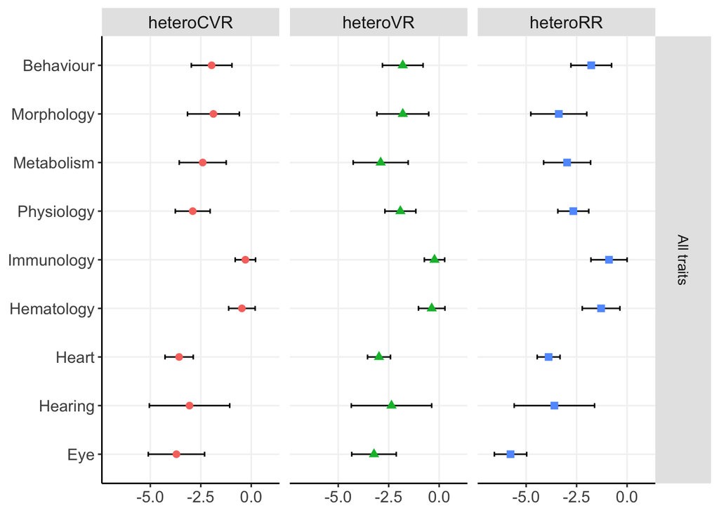

```r
Metameta_Fig4_alltraits <- heterog4 %>%

  ggplot(aes(y= GroupingTerm, x= value)) +
  geom_errorbarh(aes(xmin = ci.low,
                     xmax = ci.high),
               height = 0.1, show.legend = FALSE) +
  geom_point(aes(shape = parameter,
             fill = parameter, color = parameter), size = 2.2,
             show.legend = FALSE) +
  scale_x_continuous(limits=c(-7.0, 1),
                     #breaks = c(-2.0, -1.5, -1.0, -0.5, 0, 0.5, 1.0, 1.5, 2.0),
                     name='Effect size') +
  facet_grid(cols = vars(parameter), rows = vars(label),
             labeller = label_wrap_gen(width = 23),
             scales= 'free',
             space='free')+
  theme_bw()+
  theme(strip.text.y = element_text(angle = 270, size = 10, margin = margin(t=15, r=15, b=15, l=15)),
      strip.text.x = element_text(size = 12),
        strip.background = element_rect(colour = NULL, linetype = "blank", fill = "gray90"),
        text = element_text(size = 14),
        panel.spacing = unit(0.5, "lines"),
        panel.border= element_blank(),
        axis.line=element_line(),
        panel.grid.major.x = element_line(linetype = "solid", colour = "gray95"),
        panel.grid.major.y = element_line(linetype = "solid", color = "gray95"),
        panel.grid.minor.y = element_blank(),
        panel.grid.minor.x = element_blank(),
        legend.title = element_blank(),
        axis.title.x = element_blank(),
      axis.title.y = element_blank())

Metameta_Fig4_alltraits
```

```r
#ggsave("Fig4.pdf", plot = Metameta_Fig4_alltraits, width = 7, height = 6)
```